# case_study_umaer_jayanth#1

```python
#importing required Libraries.
import numpy as np
import pandas as pd
import matplotlib.pyplot as plt
import seaborn as sns
%matplotlib inline

import sidetable
from tabulate import tabulate

import warnings
warnings.filterwarnings('ignore')
```

```python
#setting max number of columns to be displayed to 100, to get a better view.
pd.set_option('display.max_columns',100)
pd.set_option('display.max_rows',100)
from IPython.display import HTML
HTML('''<script>
code_show_err=false;
function code_toggle_err() {
 if (code_show_err){
 $('div.output_stderr').hide();
 } else {
 $('div.output_stderr').show();
 }
 code_show_err = !code_show_err
}
$( document ).ready(code_toggle_err);
</script>
''')
```

## Loading Application Data

```python
application_data=pd.read_csv('application_data.csv')
```

```python
#checking shape
application_data.shape
```

```
(307511, 122)
```

```python
application_data.info()
```

```
<class 'pandas.core.frame.DataFrame'>
RangeIndex: 307511 entries, 0 to 307510
Columns: 122 entries, SK_ID_CURR to AMT_REQ_CREDIT_BUREAU_YEAR
dtypes: float64(65), int64(41), object(16)
memory usage: 286.2+ MB
```

```python
application_data.describe()
```

|  | SK_ID_CURR | TARGET | CNT_CHILDREN | AMT_INCOME_TOTAL | AMT_CREDIT | AMT_ANNUITY | AMT_GOODS_PRICE | REGION_POPULATION_RELATIVE | DAYS_BIRTH | DAYS_EMPLOYED | DAYS_REGISTRATION | DAYS_ID_PUBLISH | OWN_CAR_AGE | FLAG_MOBIL | FLAG_EMP_PHONE | FLAG_WORK_PHONE | FLAG_CONT_MOBILE | FLAG_PHONE | FLAG_EMAIL | CNT_FAM_MEMBERS | REGION_RATING_CLIENT | REGION_RATING_CLIENT_W_CITY | HOUR_APPR_PROCESS_START | REG_REGION_NOT_LIVE_REGION | REG_REGION_NOT_WORK_REGION | LIVE_REGION_NOT_WORK_REGION | REG_CITY_NOT_LIVE_CITY | REG_CITY_NOT_WORK_CITY | LIVE_CITY_NOT_WORK_CITY | … |
| --- | --- | --- | --- | --- | --- | --- | --- | --- | --- | --- | --- | --- | --- | --- | --- | --- | --- | --- | --- | --- | --- | --- | --- | --- | --- | --- | --- | --- | --- | --- |
| count | 307,511.00 | 307,511.00 | 307,511.00 | 307,511.00 | 307,511.00 | 307,499.00 | 307,233.00 | 307,511.00 | 307,511.00 | 307,511.00 | 307,511.00 | 307,511.00 | 104,582.00 | 307,511.00 | 307,511.00 | 307,511.00 | 307,511.00 | 307,511.00 | 307,511.00 | 307,509.00 | 307,511.00 | 307,511.00 | 307,511.00 | 307,511.00 | 307,511.00 | 307,511.00 | 307,511.00 | 307,511.00 | 307,511.00 | … |
| mean | 278,180.52 | 0.08 | 0.42 | 168,797.92 | 599,026.00 | 27,108.57 | 538,396.21 | 0.02 | -16,037.00 | 63,815.05 | -4,986.12 | -2,994.20 | 12.06 | 1.00 | 0.82 | 0.20 | 1.00 | 0.28 | 0.06 | 2.15 | 2.05 | 2.03 | 12.06 | 0.02 | 0.05 | 0.04 | 0.08 | 0.23 | 0.18 | … |
| std | 102,790.18 | 0.27 | 0.72 | 237,123.15 | 402,490.78 | 14,493.74 | 369,446.46 | 0.01 | 4,363.99 | 141,275.77 | 3,522.89 | 1,509.45 | 11.94 | 0.00 | 0.38 | 0.40 | 0.04 | 0.45 | 0.23 | 0.91 | 0.51 | 0.50 | 3.27 | 0.12 | 0.22 | 0.20 | 0.27 | 0.42 | 0.38 | … |
| min | 100,002.00 | 0.00 | 0.00 | 25,650.00 | 45,000.00 | 1,615.50 | 40,500.00 | 0.00 | -25,229.00 | -17,912.00 | -24,672.00 | -7,197.00 | 0.00 | 0.00 | 0.00 | 0.00 | 0.00 | 0.00 | 0.00 | 1.00 | 1.00 | 1.00 | 0.00 | 0.00 | 0.00 | 0.00 | 0.00 | 0.00 | 0.00 | … |
| 25% | 189,145.50 | 0.00 | 0.00 | 112,500.00 | 270,000.00 | 16,524.00 | 238,500.00 | 0.01 | -19,682.00 | -2,760.00 | -7,479.50 | -4,299.00 | 5.00 | 1.00 | 1.00 | 0.00 | 1.00 | 0.00 | 0.00 | 2.00 | 2.00 | 2.00 | 10.00 | 0.00 | 0.00 | 0.00 | 0.00 | 0.00 | 0.00 | … |
| 50% | 278,202.00 | 0.00 | 0.00 | 147,150.00 | 513,531.00 | 24,903.00 | 450,000.00 | 0.02 | -15,750.00 | -1,213.00 | -4,504.00 | -3,254.00 | 9.00 | 1.00 | 1.00 | 0.00 | 1.00 | 0.00 | 0.00 | 2.00 | 2.00 | 2.00 | 12.00 | 0.00 | 0.00 | 0.00 | 0.00 | 0.00 | 0.00 | … |
| 75% | 367,142.50 | 0.00 | 1.00 | 202,500.00 | 808,650.00 | 34,596.00 | 679,500.00 | 0.03 | -12,413.00 | -289.00 | -2,010.00 | -1,720.00 | 15.00 | 1.00 | 1.00 | 0.00 | 1.00 | 1.00 | 0.00 | 3.00 | 2.00 | 2.00 | 14.00 | 0.00 | 0.00 | 0.00 | 0.00 | 0.00 | 0.00 | … |
| max | 456,255.00 | 1.00 | 19.00 | 117,000,000.00 | 4,050,000.00 | 258,025.50 | 4,050,000.00 | 0.07 | -7,489.00 | 365,243.00 | 0.00 | 0.00 | 91.00 | 1.00 | 1.00 | 1.00 | 1.00 | 1.00 | 1.00 | 20.00 | 3.00 | 3.00 | 23.00 | 1.00 | 1.00 | 1.00 | 1.00 | 1.00 | 1.00 | … |

8 rows × 106 columns

## Data Quality Check

### Checking Columns with High Null Percentage

```python
def color_red(value):
    '''
      Colors elements in a dateframe
      green if nulls <50% and red if
      >=50%.
    '''
    if value >=50:
        color = 'red'
    elif value <50:
        color = 'green'

    return 'color: %s' % color

#Finding Percentage of Missing values in each and every column
missing_data = np.round(100*application_data.isnull().sum()/len(application_data),2)
missing_data = pd.DataFrame(data={'Column Name' :missing_data.index, 'Null Percentage' : missing_data.values})
missing_data.style.applymap(color_red,subset=['Null Percentage'])
```

|  | Column Name | Null Percentage |
| --- | --- | --- |
| 0 | SK_ID_CURR | 0.00 |
| 1 | TARGET | 0.00 |
| 2 | NAME_CONTRACT_TYPE | 0.00 |
| 3 | CODE_GENDER | 0.00 |
| 4 | FLAG_OWN_CAR | 0.00 |
| 5 | FLAG_OWN_REALTY | 0.00 |
| 6 | CNT_CHILDREN | 0.00 |
| 7 | AMT_INCOME_TOTAL | 0.00 |
| 8 | AMT_CREDIT | 0.00 |
| 9 | AMT_ANNUITY | 0.00 |
| 10 | AMT_GOODS_PRICE | 0.09 |
| 11 | NAME_TYPE_SUITE | 0.42 |
| 12 | NAME_INCOME_TYPE | 0.00 |
| 13 | NAME_EDUCATION_TYPE | 0.00 |
| 14 | NAME_FAMILY_STATUS | 0.00 |
| 15 | NAME_HOUSING_TYPE | 0.00 |
| 16 | REGION_POPULATION_RELATIVE | 0.00 |
| 17 | DAYS_BIRTH | 0.00 |
| 18 | DAYS_EMPLOYED | 0.00 |
| 19 | DAYS_REGISTRATION | 0.00 |
| 20 | DAYS_ID_PUBLISH | 0.00 |
| 21 | OWN_CAR_AGE | 65.99 |
| 22 | FLAG_MOBIL | 0.00 |
| 23 | FLAG_EMP_PHONE | 0.00 |
| 24 | FLAG_WORK_PHONE | 0.00 |
| 25 | FLAG_CONT_MOBILE | 0.00 |
| 26 | FLAG_PHONE | 0.00 |
| 27 | FLAG_EMAIL | 0.00 |
| 28 | OCCUPATION_TYPE | 31.35 |
| 29 | CNT_FAM_MEMBERS | 0.00 |

[output cut: 92 more lines]

```python
#Finding the columns that have more than or equal to 50% null values and storing it to columns_to_drop.
columns_to_drop=application_data.columns[100*application_data.isnull().sum()/len(application_data)>=50]
columns_to_drop
```

```
Index(['OWN_CAR_AGE', 'EXT_SOURCE_1', 'APARTMENTS_AVG', 'BASEMENTAREA_AVG',
       'YEARS_BUILD_AVG', 'COMMONAREA_AVG', 'ELEVATORS_AVG', 'ENTRANCES_AVG',
       'FLOORSMIN_AVG', 'LANDAREA_AVG', 'LIVINGAPARTMENTS_AVG',
       'LIVINGAREA_AVG', 'NONLIVINGAPARTMENTS_AVG', 'NONLIVINGAREA_AVG',
       'APARTMENTS_MODE', 'BASEMENTAREA_MODE', 'YEARS_BUILD_MODE',
       'COMMONAREA_MODE', 'ELEVATORS_MODE', 'ENTRANCES_MODE', 'FLOORSMIN_MODE',
       'LANDAREA_MODE', 'LIVINGAPARTMENTS_MODE', 'LIVINGAREA_MODE',
       'NONLIVINGAPARTMENTS_MODE', 'NONLIVINGAREA_MODE', 'APARTMENTS_MEDI',
       'BASEMENTAREA_MEDI', 'YEARS_BUILD_MEDI', 'COMMONAREA_MEDI',
       'ELEVATORS_MEDI', 'ENTRANCES_MEDI', 'FLOORSMIN_MEDI', 'LANDAREA_MEDI',
       'LIVINGAPARTMENTS_MEDI', 'LIVINGAREA_MEDI', 'NONLIVINGAPARTMENTS_MEDI',
       'NONLIVINGAREA_MEDI', 'FONDKAPREMONT_MODE', 'HOUSETYPE_MODE',
       'WALLSMATERIAL_MODE'],
      dtype='object')
```

```python
#dropping the columns where the null values are >= 50%.
application_data.drop(labels=columns_to_drop,axis=1,inplace=True)
```

```python
#verifying if the columns are dropped.
application_data.shape
```

```
(307511, 81)
```

## Imputation Consideration

### Finding the best values to impute below columns that have <=13% of null values

```python
#Finding columns with <= 13% missing columns

null_info = pd.DataFrame(100*application_data.isnull().sum()/len(application_data))
null_info.columns = ['Null Percentage']
null_info[(null_info['Null Percentage'] > 0) & (null_info['Null Percentage'] <=13)]
```

|  | Null Percentage |
| --- | --- |
| AMT_ANNUITY | 0.00 |
| AMT_GOODS_PRICE | 0.09 |
| NAME_TYPE_SUITE | 0.42 |
| CNT_FAM_MEMBERS | 0.00 |
| EXT_SOURCE_2 | 0.21 |
| OBS_30_CNT_SOCIAL_CIRCLE | 0.33 |
| DEF_30_CNT_SOCIAL_CIRCLE | 0.33 |
| OBS_60_CNT_SOCIAL_CIRCLE | 0.33 |
| DEF_60_CNT_SOCIAL_CIRCLE | 0.33 |
| DAYS_LAST_PHONE_CHANGE | 0.00 |

### Columns To Impute

We have chosen the following columns to consider the best value to impute the missing values with

### AMT_ANNUITY Imputation

```
Quantile	AMT_ANNUITY
```

```
0.50    24,903.00
0.80    37,516.50
0.85    40,806.00
0.90    45,954.00
0.95    53,325.00
1.00   258,025.50
Name: AMT_ANNUITY, dtype: float64
```

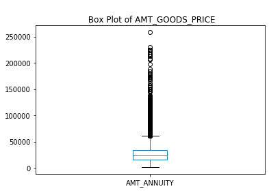

```python
# Boxplot to check for outliers
application_data['AMT_ANNUITY'].plot.box()
plt.title('\n Box Plot of AMT_GOODS_PRICE')

# Calculating Quantiles
print('Quantile\tAMT_ANNUITY')
application_data['AMT_ANNUITY'].quantile([0.5,0.8,0.85,0.90,0.95,1])
```

From the above box plot of AMT_ANNUITY, there are a lot of outliers.

Calculating Quantiles confirms the same. There is a huge jump from 95% value to max value .  
Hence, **Median : 24903** is the best value to impute the missing values in `AMT_ANNUITY`, since mean is not robust to outliers.

### AMT_GOODS_PRICE Imputation

```
Quantile	AMT_GOODS_PRICE
```

```
0.50     450,000.00
0.80     814,500.00
0.85     900,000.00
0.90   1,093,500.00
0.95   1,305,000.00
1.00   4,050,000.00
Name: AMT_GOODS_PRICE, dtype: float64
```

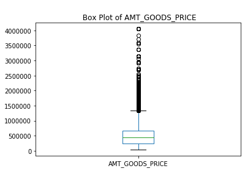

```python
print('Quantile\tAMT_GOODS_PRICE')
application_data['AMT_GOODS_PRICE'].plot.box()
plt.title('\n Box Plot of AMT_GOODS_PRICE')
application_data['AMT_GOODS_PRICE'].quantile([0.5,0.8,0.85,0.90,0.95,1])
```

The above box plot show significant number of outliers. This confirmed by the quantiles.  
There is a huge jump from 95 percentile value to Maximum value.  
In this case, since there are many outliers, Mean is not a good representation of the data since it is not robust to outliers.

Hence ,**Median : 450000** is the best metric to impute missing values

### NAME_TYPE_SUITE Imputation :

```
Data type of NAME_TYPE_SUITE :  object


Category	Normalized Count

 Unaccompanied     0.81
Family            0.13
Spouse, partner   0.04
Children          0.01
Other_B           0.01
Other_A           0.00
Group of people   0.00
Name: NAME_TYPE_SUITE, dtype: float64
```

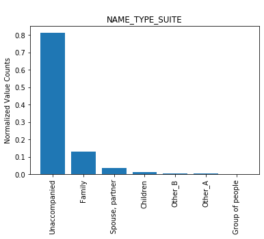

```python
print('Data type of NAME_TYPE_SUITE : ',application_data['NAME_TYPE_SUITE'].dtype,'\n\n')
print('Category\tNormalized Count\n\n',application_data['NAME_TYPE_SUITE'].value_counts(normalize=True))
data = application_data['NAME_TYPE_SUITE'].value_counts(normalize=True)
plt.bar(data.index,data.values)
# data.hist()
plt.xticks(rotation=90)
plt.ylabel('Normalized Value Counts')
plt.title('\nNAME_TYPE_SUITE');
```

`NAME_TYPE_SUITE` is a categorical variable.  
The best metric to impute missing values is Mode of the data.  
From the above plot, 'Unaccompanied' is the Mode

Hence, **Unaccompanied** is the best value to impute the missing values.

### CNT_FAM_MEMBERS Imputation

```
Data type of CNT_FAM_MEMBERS :  category


Fly Mems | Value Counts
 2.00    0.51
1.00    0.22
3.00    0.17
4.00    0.08
5.00    0.01
6.00    0.00
7.00    0.00
8.00    0.00
9.00    0.00
10.00   0.00
16.00   0.00
12.00   0.00
14.00   0.00
20.00   0.00
11.00   0.00
13.00   0.00
15.00   0.00
Name: CNT_FAM_MEMBERS, dtype: float64
```

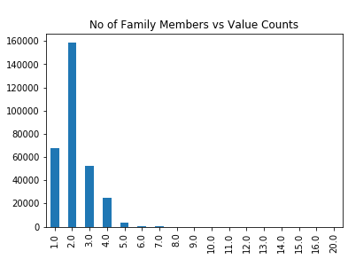

```python
application_data['CNT_FAM_MEMBERS'] = application_data['CNT_FAM_MEMBERS'].astype('category')

print('Data type of CNT_FAM_MEMBERS : ',application_data['CNT_FAM_MEMBERS'].dtype,'\n\n')

print('Fly Mems | Value Counts\n',application_data['CNT_FAM_MEMBERS'].value_counts(normalize=True))

(application_data['CNT_FAM_MEMBERS'].value_counts()).sort_index().plot(kind='bar')
plt.title('\nNo of Family Members vs Value Counts');
```

### EXT_SOURCE_2 Imputation

```
Data type of EXT_SOURCE_2 :  float64


Quantile	Value
```

```
0.50   0.57
0.80   0.68
0.85   0.70
0.90   0.72
0.95   0.75
1.00   0.85
Name: EXT_SOURCE_2, dtype: float64
```

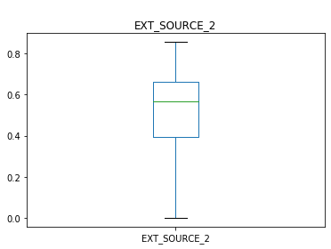

```python
print('Data type of EXT_SOURCE_2 : ',application_data['EXT_SOURCE_2'].dtype,'\n\n')
application_data['EXT_SOURCE_2'].plot.box()
plt.title('\nEXT_SOURCE_2');
print('Quantile\tValue')
application_data['EXT_SOURCE_2'].quantile([0.5,0.8,0.85,0.90,0.95,1])
```

```python
round(application_data['EXT_SOURCE_2'].mean(),2)
```

```
0.51
```

### Checking for Disguised Missing Values

```python
def cat_value_counts(column_name) :
    print(tabulate(pd.DataFrame(application_data.stb.freq([column_name])), headers='keys', tablefmt='psql'))
    print(pd.DataFrame(application_data[column_name]).stb.missing(),'\n\n\n')
```

```python
#Replacing XAN with np.nan in Gender column :

application_data['CODE_GENDER'] = application_data['CODE_GENDER'].replace('XNA',np.nan)
cat_value_counts('CODE_GENDER')
```

```
+----+---------------+---------+-----------+--------------------+----------------------+
|    | CODE_GENDER   |   Count |   Percent |   Cumulative Count |   Cumulative Percent |
|----+---------------+---------+-----------+--------------------+----------------------|
|  0 | F             |  202448 |  0.658352 |             202448 |             0.658352 |
|  1 | M             |  105059 |  0.341648 |             307507 |             1        |
+----+---------------+---------+-----------+--------------------+----------------------+
             Missing   Total  Percent
CODE_GENDER        4  307511     0.00
```

Since `CODE_GENDER` is a categorical variable, the missing values could be imputed with **Mode** : F

```python
# replacing Unknown in NAME_FAMILY_STATUS with np.nan
application_data['NAME_FAMILY_STATUS'] = application_data['NAME_FAMILY_STATUS'].replace('Unknown',np.nan)
cat_value_counts('NAME_FAMILY_STATUS')
```

```
+----+----------------------+---------+-----------+--------------------+----------------------+
|    | NAME_FAMILY_STATUS   |   Count |   Percent |   Cumulative Count |   Cumulative Percent |
|----+----------------------+---------+-----------+--------------------+----------------------|
|  0 | Married              |  196432 | 0.638785  |             196432 |             0.638785 |
|  1 | Single / not married |   45444 | 0.147781  |             241876 |             0.786566 |
|  2 | Civil marriage       |   29775 | 0.0968264 |             271651 |             0.883392 |
|  3 | Separated            |   19770 | 0.0642908 |             291421 |             0.947683 |
|  4 | Widow                |   16088 | 0.0523172 |             307509 |             1        |
+----+----------------------+---------+-----------+--------------------+----------------------+
                    Missing   Total  Percent
NAME_FAMILY_STATUS        2  307511     0.00
```

Since `NAME_FAMILY_STATUS` is a categorical variable, the missing values could be imputed with **Mode** : Married

```python
# replacing XNA values in ORGANIZATION_TYPE
application_data['ORGANIZATION_TYPE'] = application_data['ORGANIZATION_TYPE'].replace('XNA',np.nan)
cat_value_counts('ORGANIZATION_TYPE')
```

```
+----+------------------------+---------+-------------+--------------------+----------------------+
|    | ORGANIZATION_TYPE      |   Count |     Percent |   Cumulative Count |   Cumulative Percent |
|----+------------------------+---------+-------------+--------------------+----------------------|
|  0 | Business Entity Type 3 |   67992 | 0.269663    |              67992 |             0.269663 |
|  1 | Self-employed          |   38412 | 0.152346    |             106404 |             0.422009 |
|  2 | Other                  |   16683 | 0.0661664   |             123087 |             0.488175 |
|  3 | Medicine               |   11193 | 0.0443925   |             134280 |             0.532568 |
|  4 | Business Entity Type 2 |   10553 | 0.0418542   |             144833 |             0.574422 |
|  5 | Government             |   10404 | 0.0412633   |             155237 |             0.615685 |
|  6 | School                 |    8893 | 0.0352705   |             164130 |             0.650956 |
|  7 | Trade: type 7          |    7831 | 0.0310585   |             171961 |             0.682014 |
|  8 | Kindergarten           |    6880 | 0.0272868   |             178841 |             0.709301 |
|  9 | Construction           |    6721 | 0.0266561   |             185562 |             0.735957 |
| 10 | Business Entity Type 1 |    5984 | 0.0237331   |             191546 |             0.75969  |
| 11 | Transport: type 4      |    5398 | 0.021409    |             196944 |             0.781099 |
| 12 | Trade: type 3          |    3492 | 0.0138496   |             200436 |             0.794949 |
| 13 | Industry: type 9       |    3368 | 0.0133578   |             203804 |             0.808307 |
| 14 | Industry: type 3       |    3278 | 0.0130009   |             207082 |             0.821307 |
| 15 | Security               |    3247 | 0.0128779   |             210329 |             0.834185 |
| 16 | Housing                |    2958 | 0.0117317   |             213287 |             0.845917 |
| 17 | Industry: type 11      |    2704 | 0.0107243   |             215991 |             0.856641 |
| 18 | Military               |    2634 | 0.0104467   |             218625 |             0.867088 |
| 19 | Bank                   |    2507 | 0.00994301  |             221132 |             0.877031 |
| 20 | Agriculture            |    2454 | 0.0097328   |             223586 |             0.886764 |
| 21 | Police                 |    2341 | 0.00928463  |             225927 |             0.896049 |
| 22 | Transport: type 2      |    2204 | 0.00874128  |             228131 |             0.90479  |
| 23 | Postal                 |    2157 | 0.00855487  |             230288 |             0.913345 |
| 24 | Security Ministries    |    1974 | 0.00782908  |             232262 |             0.921174 |
| 25 | Trade: type 2          |    1900 | 0.00753559  |             234162 |             0.928709 |
| 26 | Restaurant             |    1811 | 0.0071826   |             235973 |             0.935892 |
| 27 | Services               |    1575 | 0.0062466   |             237548 |             0.942139 |
| 28 | University             |    1327 | 0.00526301  |             238875 |             0.947402 |
| 29 | Industry: type 7       |    1307 | 0.00518369  |             240182 |             0.952585 |
| 30 | Transport: type 3      |    1187 | 0.00470776  |             241369 |             0.957293 |
| 31 | Industry: type 1       |    1039 | 0.00412078  |             242408 |             0.961414 |
| 32 | Hotel                  |     966 | 0.00383125  |             243374 |             0.965245 |
| 33 | Electricity            |     950 | 0.00376779  |             244324 |             0.969013 |
| 34 | Industry: type 4       |     877 | 0.00347827  |             245201 |             0.972491 |
| 35 | Trade: type 6          |     631 | 0.00250261  |             245832 |             0.974994 |
| 36 | Industry: type 5       |     599 | 0.00237569  |             246431 |             0.977369 |
```

[output cut: 8 more lines]

```
| 45 | Trade: type 1          |     348 | 0.0013802   |             250544 |             0.993682 |
| 46 | Mobile                 |     317 | 0.00125725  |             250861 |             0.994939 |
| 47 | Legal Services         |     305 | 0.00120966  |             251166 |             0.996149 |
| 48 | Cleaning               |     260 | 0.00103119  |             251426 |             0.99718  |
| 49 | Transport: type 1      |     201 | 0.000797186 |             251627 |             0.997977 |
| 50 | Industry: type 6       |     112 | 0.000444203 |             251739 |             0.998421 |
| 51 | Industry: type 10      |     109 | 0.000432305 |             251848 |             0.998854 |
| 52 | Religion               |      85 | 0.000337118 |             251933 |             0.999191 |
| 53 | Industry: type 13      |      67 | 0.000265729 |             252000 |             0.999457 |
| 54 | Trade: type 4          |      64 | 0.00025383  |             252064 |             0.99971  |
| 55 | Trade: type 5          |      49 | 0.000194339 |             252113 |             0.999905 |
| 56 | Industry: type 8       |      24 | 9.51863e-05 |             252137 |             1        |
+----+------------------------+---------+-------------+--------------------+----------------------+
                   Missing   Total  Percent
ORGANIZATION_TYPE    55374  307511     0.18
```

Since `ORGANIZATION_TYPE` is a categorical variable, the missing values could be imputed with **Mode** : Business Entity Type 3

### Data Type Checks

```python
pd.DataFrame(application_data.dtypes)
```

|  | 0 |
| --- | --- |
| SK_ID_CURR | int64 |
| TARGET | int64 |
| NAME_CONTRACT_TYPE | object |
| CODE_GENDER | object |
| FLAG_OWN_CAR | object |
| FLAG_OWN_REALTY | object |
| CNT_CHILDREN | int64 |
| AMT_INCOME_TOTAL | float64 |
| AMT_CREDIT | float64 |
| AMT_ANNUITY | float64 |
| AMT_GOODS_PRICE | float64 |
| NAME_TYPE_SUITE | object |
| NAME_INCOME_TYPE | object |
| NAME_EDUCATION_TYPE | object |
| NAME_FAMILY_STATUS | object |
| NAME_HOUSING_TYPE | object |
| REGION_POPULATION_RELATIVE | float64 |
| DAYS_BIRTH | int64 |
| DAYS_EMPLOYED | int64 |
| DAYS_REGISTRATION | float64 |
| DAYS_ID_PUBLISH | int64 |
| FLAG_MOBIL | int64 |
| FLAG_EMP_PHONE | int64 |
| FLAG_WORK_PHONE | int64 |
| FLAG_CONT_MOBILE | int64 |
| FLAG_PHONE | int64 |
| FLAG_EMAIL | int64 |
| OCCUPATION_TYPE | object |
| CNT_FAM_MEMBERS | category |
| REGION_RATING_CLIENT | int64 |

[output cut: 51 more lines]

```python
application_data[['DAYS_BIRTH','DAYS_EMPLOYED','DAYS_REGISTRATION','DAYS_ID_PUBLISH']].head()
```

|  | DAYS_BIRTH | DAYS_EMPLOYED | DAYS_REGISTRATION | DAYS_ID_PUBLISH |
| --- | --- | --- | --- | --- |
| 0 | -9461 | -637 | -3,648.00 | -2120 |
| 1 | -16765 | -1188 | -1,186.00 | -291 |
| 2 | -19046 | -225 | -4,260.00 | -2531 |
| 3 | -19005 | -3039 | -9,833.00 | -2437 |
| 4 | -19932 | -3038 | -4,311.00 | -3458 |

The `DAYS_BIRTH`,`DAYS_EMPLOYED`,`DAYS_REGISTRATION`,`DAYS_ID_PUBLISH` have negative values, since they are in past with respect to date of application.  
To standard size these columns for the purpose of analysis, we could converted them to their absolute values

```python
columns_to_convert = ['DAYS_BIRTH','DAYS_EMPLOYED','DAYS_REGISTRATION','DAYS_ID_PUBLISH']
application_data[columns_to_convert] = application_data[columns_to_convert].abs()
application_data[columns_to_convert].head()
```

|  | DAYS_BIRTH | DAYS_EMPLOYED | DAYS_REGISTRATION | DAYS_ID_PUBLISH |
| --- | --- | --- | --- | --- |
| 0 | 9,461.00 | 637.00 | 3,648.00 | 2,120.00 |
| 1 | 16,765.00 | 1,188.00 | 1,186.00 | 291.00 |
| 2 | 19,046.00 | 225.00 | 4,260.00 | 2,531.00 |
| 3 | 19,005.00 | 3,039.00 | 9,833.00 | 2,437.00 |
| 4 | 19,932.00 | 3,038.00 | 4,311.00 | 3,458.00 |

```python
# checking columns with binary values
values_per_column = application_data.nunique().sort_values()
col_values_dtype = pd.DataFrame(index=values_per_column.index, data= {'Unique Values' : values_per_column.values, 'Data Type' : application_data.dtypes})
col_values_dtype
```

|  | Unique Values | Data Type |
| --- | --- | --- |
| FLAG_DOCUMENT_3 | 2 | int64 |
| FLAG_PHONE | 2 | int64 |
| FLAG_DOCUMENT_4 | 2 | int64 |
| FLAG_DOCUMENT_2 | 2 | int64 |
| REG_REGION_NOT_LIVE_REGION | 2 | int64 |
| REG_REGION_NOT_WORK_REGION | 2 | int64 |
| LIVE_REGION_NOT_WORK_REGION | 2 | int64 |
| REG_CITY_NOT_LIVE_CITY | 2 | int64 |
| REG_CITY_NOT_WORK_CITY | 2 | int64 |
| LIVE_CITY_NOT_WORK_CITY | 2 | int64 |
| FLAG_DOCUMENT_14 | 2 | int64 |
| FLAG_DOCUMENT_13 | 2 | int64 |
| FLAG_DOCUMENT_12 | 2 | int64 |
| FLAG_DOCUMENT_11 | 2 | int64 |
| FLAG_DOCUMENT_10 | 2 | int64 |
| FLAG_DOCUMENT_9 | 2 | int64 |
| FLAG_DOCUMENT_8 | 2 | int64 |
| FLAG_DOCUMENT_7 | 2 | int64 |
| EMERGENCYSTATE_MODE | 2 | object |
| FLAG_DOCUMENT_6 | 2 | int64 |
| FLAG_CONT_MOBILE | 2 | int64 |
| FLAG_WORK_PHONE | 2 | int64 |
| FLAG_EMAIL | 2 | int64 |
| FLAG_MOBIL | 2 | int64 |
| TARGET | 2 | int64 |
| NAME_CONTRACT_TYPE | 2 | object |
| CODE_GENDER | 2 | object |
| FLAG_OWN_CAR | 2 | object |
| FLAG_OWN_REALTY | 2 | object |
| FLAG_DOCUMENT_21 | 2 | int64 |

[output cut: 51 more lines]

The above columns are 'categorical' variables with only two values. But they have been read as 'int' datatype  
We could convert them into 'categorical' data type

```python
# converting to category data type
convert_to_cat = col_values_dtype[col_values_dtype['Unique Values']<=8].index
application_data[convert_to_cat] = application_data[convert_to_cat].astype('category')
```

```python
# check if the columns are converted
values_per_column = application_data.nunique().sort_values()
new_categories  = pd.DataFrame(index=values_per_column.index, data= {'Unique Values' : values_per_column.values, 'Data Type' : application_data.dtypes})
new_categories
```

|  | Unique Values | Data Type |
| --- | --- | --- |
| FLAG_DOCUMENT_3 | 2 | category |
| FLAG_PHONE | 2 | category |
| FLAG_DOCUMENT_4 | 2 | category |
| FLAG_DOCUMENT_2 | 2 | category |
| REG_REGION_NOT_LIVE_REGION | 2 | category |
| REG_REGION_NOT_WORK_REGION | 2 | category |
| LIVE_REGION_NOT_WORK_REGION | 2 | category |
| REG_CITY_NOT_LIVE_CITY | 2 | category |
| REG_CITY_NOT_WORK_CITY | 2 | category |
| LIVE_CITY_NOT_WORK_CITY | 2 | category |
| FLAG_DOCUMENT_14 | 2 | category |
| FLAG_DOCUMENT_13 | 2 | category |
| FLAG_DOCUMENT_12 | 2 | category |
| FLAG_DOCUMENT_11 | 2 | category |
| FLAG_DOCUMENT_10 | 2 | category |
| FLAG_DOCUMENT_9 | 2 | category |
| FLAG_DOCUMENT_8 | 2 | category |
| FLAG_DOCUMENT_7 | 2 | category |
| EMERGENCYSTATE_MODE | 2 | category |
| FLAG_DOCUMENT_6 | 2 | category |
| FLAG_CONT_MOBILE | 2 | category |
| FLAG_WORK_PHONE | 2 | category |
| FLAG_EMAIL | 2 | category |
| FLAG_MOBIL | 2 | category |
| TARGET | 2 | category |
| NAME_CONTRACT_TYPE | 2 | category |
| CODE_GENDER | 2 | category |
| FLAG_OWN_CAR | 2 | category |
| FLAG_OWN_REALTY | 2 | category |
| FLAG_DOCUMENT_21 | 2 | category |

[output cut: 51 more lines]

### Checking for outliers in the following numerical columns

- AMT_INCOME_TOTAL
- AMT_CREDIT
- AMT_ANNUITY
- AMT_GOODS_PRICE
- DAYS_BIRTH

```python
# Adding a new column "AGE_YEARS" using 'DAYS_BIRTH' with age in years
def days_to_years(x) :
    if x < 0 :
        x = -1*x
    return x//365
application_data['AGE_YEARS'] = application_data['DAYS_BIRTH'].apply(days_to_years)
application_data['AGE_YEARS'].describe()
```

```
count   307,511.00
mean         43.44
std          11.95
min          20.00
25%          34.00
50%          43.00
75%          53.00
max          69.00
Name: AGE_YEARS, dtype: float64
```

```
Box Plots of "AMT_INCOME_TOTAL","AMT_CREDIT","AMT_ANNUITY","AMT_GOODS_PRICE","DAYS_BIRTH"
```

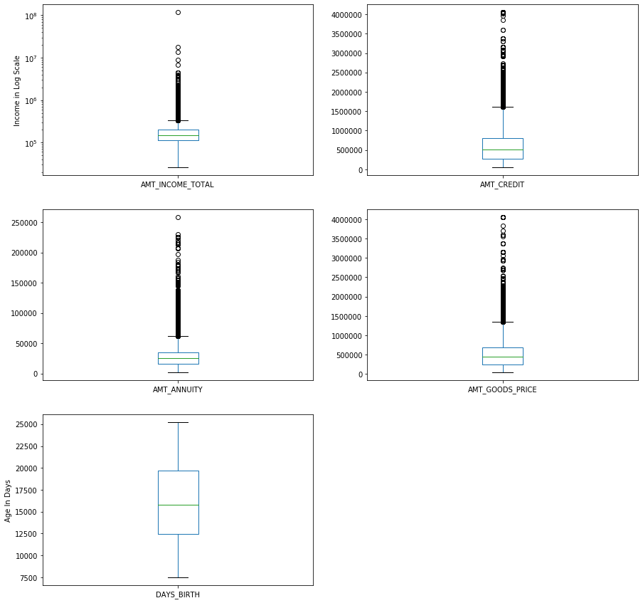

```python
# Box plots of the above numerical variables
outlier_check_col = ["AMT_INCOME_TOTAL","AMT_CREDIT","AMT_ANNUITY","AMT_GOODS_PRICE","DAYS_BIRTH"]

fig,ax = plt.subplots(3,2)
fig.set_figheight(15)
fig.set_figwidth(15)
ax[0,0].set_yscale('log')
ax[0,0].set(ylabel ='Income in Log Scale')
application_data[outlier_check_col[0]].plot.box(ax=ax[0,0],);
application_data[outlier_check_col[1]].plot.box(ax=ax[0,1]);
application_data[outlier_check_col[2]].plot.box(ax=ax[1,0]);
application_data[outlier_check_col[3]].plot.box(ax=ax[1,1]);
ax[2,0].set(ylabel ='Age In Days')
application_data[outlier_check_col[4]].plot.box(ax=ax[2,0]);
ax[2,1].axis('off')
print('Box Plots of "AMT_INCOME_TOTAL","AMT_CREDIT","AMT_ANNUITY","AMT_GOODS_PRICE","DAYS_BIRTH" \n')
```

```python
## Calculating quantiles for the above columns
pd.options.display.float_format = '{:,.2f}'.format
for col in outlier_check_col :
    print(col,'\n',application_data[col].quantile([0.5,0.8,0.85,0.90,0.95,1]),'\n\n')
```

```
AMT_INCOME_TOTAL
 0.50       147,150.00
0.80       225,000.00
0.85       234,000.00
0.90       270,000.00
0.95       337,500.00
1.00   117,000,000.00
Name: AMT_INCOME_TOTAL, dtype: float64


AMT_CREDIT
 0.50     513,531.00
0.80     900,000.00
0.85   1,024,740.00
0.90   1,133,748.00
0.95   1,350,000.00
1.00   4,050,000.00
Name: AMT_CREDIT, dtype: float64


AMT_ANNUITY
 0.50    24,903.00
0.80    37,516.50
0.85    40,806.00
0.90    45,954.00
0.95    53,325.00
1.00   258,025.50
Name: AMT_ANNUITY, dtype: float64


AMT_GOODS_PRICE
 0.50     450,000.00
0.80     814,500.00
0.85     900,000.00
0.90   1,093,500.00
0.95   1,305,000.00
1.00   4,050,000.00
Name: AMT_GOODS_PRICE, dtype: float64


DAYS_BIRTH
 0.50   15,750.00
0.80   20,474.00
0.85   21,316.00
0.90   22,181.00
0.95   23,204.00
1.00   25,229.00
Name: DAYS_BIRTH, dtype: float64
```

#### Outliers in Numerical Columns

From the above box plots and quantile calculations, we see that  
`AMT_INCOME_TOTAL` has huge jump from 95th Percentile (337,500.00) to Maximum value (117,000,000.00) {346 times 95th Percentile}.  
Apart from this jump, there are several values > 1.5 times IQR. All of these are deemed outliers.  
To avoid skewed results of analysis, values greater than 95th percentile value may be capped to 95th Percentile value (337,500.00)

`AMT_CREDIT` also has a huge jump from 95th Percentile (1,350,000.00) to Maximum value (4,050,000.00) {3 times 95th percentile}.  
Apart from this jump, there are several values > 1.5 times IQR. All of these are deemed outliers.  
To avoid skewed results of analysis, values greater than 95th percentile value may be capped to 95th Percentile value (1,350,000.00)

Similarly , `AMT_ANNUITY`, `AMT_ANNUITY` have outliers and they could be capped to 95th percentile values.

`DAYS_BIRTH` has no outliers

### Binning Continuous Variables

```
Income Range	 Count
125000-150000       47890
100000-125000       43701
200000-225000       40797
75000-100000        39806
150000-175000       34663
175000-200000       29644
50000-75000         19375
250000-275000       12733
225000-250000        7340
300000-325000        6752
350000-375000        4537
25000-50000          4517
275000-300000        4306
425000-450000        3113
500000 and above     2702
325000-350000        2122
400000-425000        1811
375000-400000        1265
475000-500000         312
450000-475000         125
0-25000                 0
Name: AMT_INCOME_CAT, dtype: int64
```

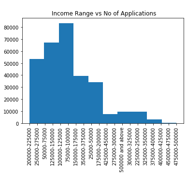

```python
# AMT_INCOME_TOTAL
min_income = int(application_data['AMT_INCOME_TOTAL'].min())
max_income = int(application_data['AMT_INCOME_TOTAL'].max())


bins = [0,25000,50000,75000,100000,125000,150000,175000,200000,225000,250000,275000,300000,325000,350000,375000,400000,425000,450000,475000,500000,10000000000]
intervals = ['0-25000', '25000-50000','50000-75000','75000-100000','100000-125000', '125000-150000', '150000-175000','175000-200000',
       '200000-225000','225000-250000','250000-275000','275000-300000','300000-325000','325000-350000','350000-375000',
       '375000-400000','400000-425000','425000-450000','450000-475000','475000-500000','500000 and above']

application_data['AMT_INCOME_CAT']=pd.cut(application_data['AMT_INCOME_TOTAL'],bins,labels=intervals)
print('Income Range\t Count')
print(application_data['AMT_INCOME_CAT'].value_counts())

income_cat = application_data['AMT_INCOME_CAT'].value_counts()
plt.hist(application_data['AMT_INCOME_CAT'])

plt.title('\n Income Range vs No of Applications')
plt.xticks(rotation=90);
```

```
Credit Range	 Count
900000 and above    58912
250000-300000       31759
200000-250000       23054
500000-550000       22678
400000-450000       18239
0-150000            18159
150000-200000       17985
300000-350000       16205
650000-700000       15051
450000-500000       13799
750000-800000       12380
800000-850000       11559
550000-600000       11554
850000-900000       10233
350000-400000       10133
600000-650000        8998
700000-750000        6813
Name: AMT_CREDIT_RANGE, dtype: int64
```

```
([0, 1, 2, 3, 4, 5, 6, 7, 8, 9, 10, 11, 12, 13, 14, 15, 16],
 <a list of 17 Text xticklabel objects>)
```

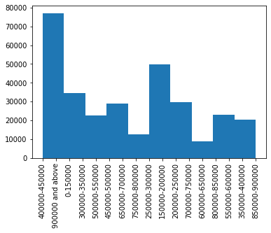

```python
#AMT_CREDIT
bins = [0,150000,200000,250000,300000,350000,400000,450000,500000,550000,600000,650000,700000,750000,800000,850000,900000,1000000000]
intervals = ['0-150000', '150000-200000','200000-250000', '250000-300000', '300000-350000', '350000-400000','400000-450000',
        '450000-500000','500000-550000','550000-600000','600000-650000','650000-700000','700000-750000','750000-800000',
        '800000-850000','850000-900000','900000 and above']

application_data['AMT_CREDIT_RANGE']=pd.cut(application_data['AMT_CREDIT'],bins=bins,labels=intervals)
application_data['AMT_CREDIT_RANGE'] = application_data['AMT_CREDIT_RANGE'].astype('category')
print('Credit Range\t Count')
credit_range = application_data['AMT_CREDIT_RANGE'].value_counts()
print(credit_range)
plt.hist(application_data['AMT_CREDIT_RANGE'])
plt.xticks(rotation=90)
```

## Data Imbalance

```python
# Target Variable - 1: Client with Payment difficulties, 0 : All other cases
cat_value_counts('TARGET')
```

```
+----+----------+---------+-----------+--------------------+----------------------+
|    |   TARGET |   Count |   Percent |   Cumulative Count |   Cumulative Percent |
|----+----------+---------+-----------+--------------------+----------------------|
|  0 |        0 |  282686 | 0.919271  |             282686 |             0.919271 |
|  1 |        1 |   24825 | 0.0807288 |             307511 |             1        |
+----+----------+---------+-----------+--------------------+----------------------+
        Missing   Total  Percent
TARGET        0  307511     0.00
```

## Data Set division wrt `TARGET`

```python
application_data0=application_data.loc[application_data["TARGET"]==0]
application_data1=application_data.loc[application_data["TARGET"]==1]
```

## Columns Selection for Analysis

```python
columnsForAnalysis = ['SK_ID_CURR', 'TARGET', 'NAME_CONTRACT_TYPE', 'CODE_GENDER',
       'FLAG_OWN_CAR', 'FLAG_OWN_REALTY', 'CNT_CHILDREN', 'AMT_INCOME_TOTAL',
       'AMT_CREDIT', 'AMT_ANNUITY', 'AMT_GOODS_PRICE',
       'NAME_INCOME_TYPE', 'NAME_EDUCATION_TYPE', 'NAME_FAMILY_STATUS',
       'NAME_HOUSING_TYPE',
       'DAYS_EMPLOYED','FLAG_MOBIL', 'FLAG_CONT_MOBILE',
       'FLAG_EMAIL', 'OCCUPATION_TYPE', 'CNT_FAM_MEMBERS',
       'REGION_RATING_CLIENT_W_CITY',
                      'REG_CITY_NOT_LIVE_CITY',
       'REG_CITY_NOT_WORK_CITY', 'LIVE_CITY_NOT_WORK_CITY',
       'ORGANIZATION_TYPE', 'EXT_SOURCE_2', 'EXT_SOURCE_3',
        'DAYS_LAST_PHONE_CHANGE' ,'AGE_YEARS', 'AMT_INCOME_CAT',
       'AMT_CREDIT_RANGE']
```

## Analysis

### Univariate Analysis

```python
# LOAN DATA
```

```python
# function for categorical variable univariate analysis
def cat_univariate_analysis(column_name,figsize=(10,5)) :
    # print unique values
    print('TARGET 0\n', application_data0[column_name].unique(),'\n')
    print('TARGET 1\n',application_data1[column_name].unique(),'\n')

    # column vs target count plot
    plt.figure(figsize=figsize)
    ax = sns.countplot(x=column_name,hue='TARGET',data=application_data)
    title = column_name + ' vs Number of Applications'
    ax.set(title= title)
    for p in ax.patches:
        height = p.get_height()
        ax.text(p.get_x()+p.get_width()/2,
                height + 10,
                format(height),
                ha="center")
    # Percentages
    print('All Other Cases (TARGET : 0)')
    print(tabulate(pd.DataFrame(application_data0.stb.freq([column_name])), headers='keys', tablefmt='psql'),'\n')
    print('Clients with Payment Difficulties (TARGET : 1)')
    print(tabulate(pd.DataFrame(application_data1.stb.freq([column_name])), headers='keys', tablefmt='psql'),'\n')
```

```
TARGET 0
 [Cash loans, Revolving loans]
Categories (2, object): [Cash loans, Revolving loans]

TARGET 1
 [Cash loans, Revolving loans]
Categories (2, object): [Cash loans, Revolving loans]

All Other Cases (TARGET : 0)
+----+----------------------+---------+-----------+--------------------+----------------------+
|    | NAME_CONTRACT_TYPE   |   Count |   Percent |   Cumulative Count |   Cumulative Percent |
|----+----------------------+---------+-----------+--------------------+----------------------|
|  0 | Cash loans           |  255011 | 0.9021    |             255011 |               0.9021 |
|  1 | Revolving loans      |   27675 | 0.0979001 |             282686 |               1      |
+----+----------------------+---------+-----------+--------------------+----------------------+

Clients with Payment Difficulties (TARGET : 1)
+----+----------------------+---------+-----------+--------------------+----------------------+
|    | NAME_CONTRACT_TYPE   |   Count |   Percent |   Cumulative Count |   Cumulative Percent |
|----+----------------------+---------+-----------+--------------------+----------------------|
|  0 | Cash loans           |   23221 | 0.935388  |              23221 |             0.935388 |
|  1 | Revolving loans      |    1604 | 0.0646123 |              24825 |             1        |
+----+----------------------+---------+-----------+--------------------+----------------------+
```

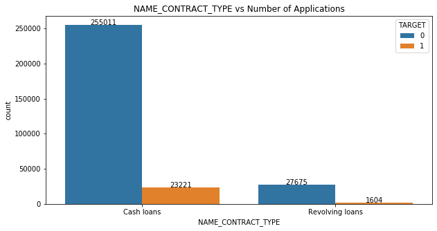

```python
# NAME_CONTRACT_TYPE
cat_univariate_analysis('NAME_CONTRACT_TYPE')
```

##### Client's with All other cases (Target=0)

- Out of 'All other cases', 90.21% have taken 'Cash Loans' and 9.79% have taken 'Revolving Loans'

##### Client's with Payment Difficulties (Target=1)

- Out of all 'Client's with payment difficulties', 93.54% have taken 'Cash Loans' and 6.46% have taken 'Revolving Loans'

```python
# function for numerical variable univariate analysis

def num_univariate_analysis(column_name,scale='linear') :
    # boxplot for column vs target
    plt.figure(figsize=(8,6))
    ax = sns.boxplot(x='TARGET', y = column_name, data = application_data)
    title = column_name+' vs Target'
    ax.set(title=title)
    if scale == 'log' :
        plt.yscale('log')
        ax.set(ylabel=column_name + '(Log Scale)')
    # summary statistic
    print('All Other Cases (TARGET : 0)')
    print(application_data0[column_name].describe(),'\n')
    print('Clients with Payment Difficulties (TARGET : 1)')
    print(application_data1[column_name].describe())
```

```
All Other Cases (TARGET : 0)
count     282,686.00
mean      602,648.28
std       406,845.91
min        45,000.00
25%       270,000.00
50%       517,788.00
75%       810,000.00
max     4,050,000.00
Name: AMT_CREDIT, dtype: float64

Clients with Payment Difficulties (TARGET : 1)
count      24,825.00
mean      557,778.53
std       346,433.24
min        45,000.00
25%       284,400.00
50%       497,520.00
75%       733,315.50
max     4,027,680.00
Name: AMT_CREDIT, dtype: float64
```

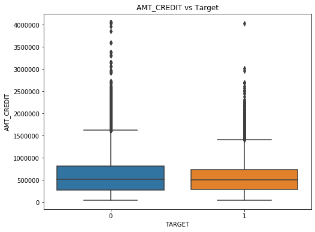

```python
# AMT_CREDIT
num_univariate_analysis('AMT_CREDIT')
```

#### Amount of credit

- The median amount of credit taken by Clients having payment difficulties' is almost same as 'All other cases'.
- You could notice that the IQR of Target 1 is less than Target 0, which implies that more proportion of client's with payment difficulties take credit amounts centered around the median amount than 'All other cases'
- Comparing the outliers of Target 1 and 0, we could see that Clients with payment difficulties favour lower amount of credit than all other cases. Conversly, people with higher amount of credit have are more probably to fall in the category 'All other cases' than 'Clients with Payment Difficulties'

```
All Other Cases (TARGET : 0)
count   282,674.00
mean     27,163.62
std      14,658.31
min       1,615.50
25%      16,456.50
50%      24,876.00
75%      34,749.00
max     258,025.50
Name: AMT_ANNUITY, dtype: float64

Clients with Payment Difficulties (TARGET : 1)
count    24,825.00
mean     26,481.74
std      12,450.68
min       2,722.50
25%      17,361.00
50%      25,263.00
75%      32,976.00
max     149,211.00
Name: AMT_ANNUITY, dtype: float64
```

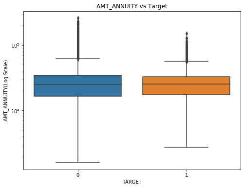

```python
#AMT_ANNUITY
num_univariate_analysis('AMT_ANNUITY','log')
```

#### Amount of Annuity

- There is not much difference in Amount of Annuity between Clients with Payment Difficulties and All other cases.
- The median and mean are around the same.
- However, Clients with Payment difficulties have annuity amounts which are less dispersed than All other cases.

```
All Other Cases (TARGET : 0)
count     282,429.00
mean      542,736.80
std       373,785.49
min        40,500.00
25%       238,500.00
50%       450,000.00
75%       688,500.00
max     4,050,000.00
Name: AMT_GOODS_PRICE, dtype: float64

Clients with Payment Difficulties (TARGET : 1)
count      24,804.00
mean      488,972.41
std       311,636.50
min        45,000.00
25%       238,500.00
50%       450,000.00
75%       675,000.00
max     3,600,000.00
Name: AMT_GOODS_PRICE, dtype: float64
```

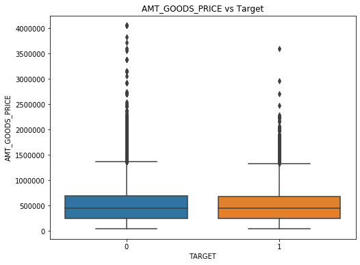

```python
#AMT_GOODS_PRICE
num_univariate_analysis('AMT_GOODS_PRICE')
```

#### Goods Price Amount

- With respect to `AMT_GOODS_PRICE`, there is no significant difference between Clients with Payment difficulties and All another Cases.

```
TARGET 0
 [1, 2, 3]
Categories (3, int64): [1, 2, 3]

TARGET 1
 [2, 3, 1]
Categories (3, int64): [2, 3, 1]

All Other Cases (TARGET : 0)
+----+-------------------------------+---------+-----------+--------------------+----------------------+
|    |   REGION_RATING_CLIENT_W_CITY |   Count |   Percent |   Cumulative Count |   Cumulative Percent |
|----+-------------------------------+---------+-----------+--------------------+----------------------|
|  0 |                             2 |  211314 |  0.747522 |             211314 |             0.747522 |
|  1 |                             3 |   38859 |  0.137463 |             250173 |             0.884985 |
|  2 |                             1 |   32513 |  0.115015 |             282686 |             1        |
+----+-------------------------------+---------+-----------+--------------------+----------------------+

Clients with Payment Difficulties (TARGET : 1)
+----+-------------------------------+---------+-----------+--------------------+----------------------+
|    |   REGION_RATING_CLIENT_W_CITY |   Count |   Percent |   Cumulative Count |   Cumulative Percent |
|----+-------------------------------+---------+-----------+--------------------+----------------------|
|  0 |                             2 |   18170 | 0.731923  |              18170 |             0.731923 |
|  1 |                             3 |    5001 | 0.20145   |              23171 |             0.933374 |
|  2 |                             1 |    1654 | 0.0666264 |              24825 |             1        |
+----+-------------------------------+---------+-----------+--------------------+----------------------+
```

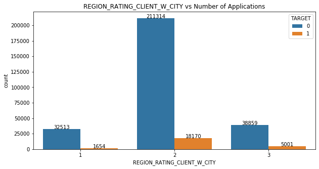

```python
#REGION_RATING_CLIENT_W_CITY
cat_univariate_analysis('REGION_RATING_CLIENT_W_CITY')
```

#### Bank City Rating

The bank has rated cities into three categories [1,2,3]

- Among 'All other cases' , 74.7% belong to category 2 cities followed by 13.7% in category 3 cities and 11.5% in category 1 cities.
- 73.1% of Clients with Payment difficulties belong to cities of category 2 followed by 20.1% belonging to category 3 and 6.6% in category 1

```
All Other Cases (TARGET : 0)
count   282,078.00
mean          0.52
std           0.19
min           0.00
25%           0.41
50%           0.57
75%           0.67
max           0.85
Name: EXT_SOURCE_2, dtype: float64

Clients with Payment Difficulties (TARGET : 1)
count   24,773.00
mean         0.41
std          0.21
min          0.00
25%          0.24
50%          0.44
75%          0.59
max          0.81
Name: EXT_SOURCE_2, dtype: float64
```

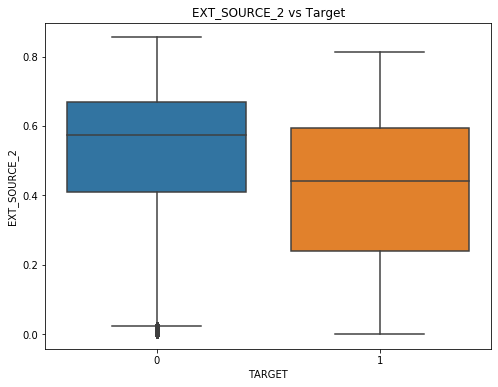

```python
#EXT_SOURCE_2
num_univariate_analysis('EXT_SOURCE_2')
```

#### Client Credit Rating By External Source - 2

- The median credit rating of clients with Payment difficulties (0.44) is less than those with all other cases (0.57)
- We can say that there is higher probability of client with less credit rating to have payment difficulties.
- Further, there are some outliers in 'All other cases'. These could be clients with no credit history and hence their credit ratings are marked as zero.

```
All Other Cases (TARGET : 0)
count   227,398.00
mean          0.52
std           0.19
min           0.00
25%           0.39
50%           0.55
75%           0.67
max           0.89
Name: EXT_SOURCE_3, dtype: float64

Clients with Payment Difficulties (TARGET : 1)
count   19,148.00
mean         0.39
std          0.21
min          0.00
25%          0.22
50%          0.38
75%          0.55
max          0.90
Name: EXT_SOURCE_3, dtype: float64
```

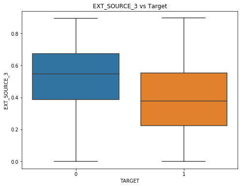

```python
#EXT_SOURCE_3
num_univariate_analysis('EXT_SOURCE_3')
```

#### Client Credit Rating By External Source - 3

- The median credit rating of clients with Payment difficulties (0.38) is less than those with all other cases (0.55)
- We can say that there is higher probability of client with less credit rating to have payment difficulties.

```
TARGET 0
 [F, M, NaN]
Categories (2, object): [F, M]

TARGET 1
 [M, F]
Categories (2, object): [M, F]

All Other Cases (TARGET : 0)
+----+---------------+---------+-----------+--------------------+----------------------+
|    | CODE_GENDER   |   Count |   Percent |   Cumulative Count |   Cumulative Percent |
|----+---------------+---------+-----------+--------------------+----------------------|
|  0 | F             |  188278 |  0.666042 |             188278 |             0.666042 |
|  1 | M             |   94404 |  0.333958 |             282682 |             1        |
+----+---------------+---------+-----------+--------------------+----------------------+

Clients with Payment Difficulties (TARGET : 1)
+----+---------------+---------+-----------+--------------------+----------------------+
|    | CODE_GENDER   |   Count |   Percent |   Cumulative Count |   Cumulative Percent |
|----+---------------+---------+-----------+--------------------+----------------------|
|  0 | F             |   14170 |  0.570796 |              14170 |             0.570796 |
|  1 | M             |   10655 |  0.429204 |              24825 |             1        |
+----+---------------+---------+-----------+--------------------+----------------------+
```

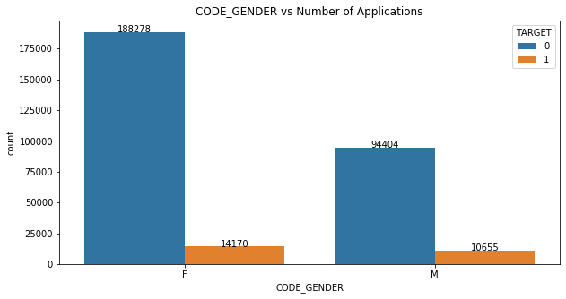

```python
#CODE_GENDER
cat_univariate_analysis('CODE_GENDER')
```

```python
print(application_data['CODE_GENDER'].value_counts(),'\n')
print('Proportion of Females (Target 0) :', round(100*188278/202448,2))
print('Proportion of Females (Target 1) :', round(100*14170/202448,2))
```

```
F    202448
M    105059
Name: CODE_GENDER, dtype: int64

Proportion of Females (Target 0) : 93.0
Proportion of Females (Target 1) : 7.0
```

```python
print('Proportion of Males (Target 0) :', round(100*94404/105059,2))
print('Proportion of Males (Target 1) :', round(100*10655/105059,2))
```

```
Proportion of Males (Target 0) : 89.86
Proportion of Males (Target 1) : 10.14
```

#### Gender

- There are very high proportion of Female applicants (65.8%)
- Only 7% of total female applicants have payment difficulties compared to 10% of total male applications.
- It is possible that female applicants are safer borrowers than male.

```python
def cat_proportions(column_name) :
    values = application_data[column_name].unique()
    values = values.to_numpy()
    values.tolist()
    data0 = application_data0[column_name].value_counts().to_dict()
    data1 = application_data1[column_name].value_counts().to_dict()
    data = application_data[column_name].value_counts().to_dict()


    for i in values :
        if i in data0 and i in data1 and i in data :
            print('Proportion of '+ str(i) + ' in Target 0 : ', round(data0[i]*100/data[i],2))
            print('Proportion of '+ str(i) + ' in Target 1 : ', round(data1[i]*100/data[i],2),'\n' )
```

```
TARGET 0
 [N, Y]
Categories (2, object): [N, Y]

TARGET 1
 [N, Y]
Categories (2, object): [N, Y]

All Other Cases (TARGET : 0)
+----+----------------+---------+-----------+--------------------+----------------------+
|    | FLAG_OWN_CAR   |   Count |   Percent |   Cumulative Count |   Cumulative Percent |
|----+----------------+---------+-----------+--------------------+----------------------|
|  0 | N              |  185675 |  0.656824 |             185675 |             0.656824 |
|  1 | Y              |   97011 |  0.343176 |             282686 |             1        |
+----+----------------+---------+-----------+--------------------+----------------------+

Clients with Payment Difficulties (TARGET : 1)
+----+----------------+---------+-----------+--------------------+----------------------+
|    | FLAG_OWN_CAR   |   Count |   Percent |   Cumulative Count |   Cumulative Percent |
|----+----------------+---------+-----------+--------------------+----------------------|
|  0 | N              |   17249 |  0.694824 |              17249 |             0.694824 |
|  1 | Y              |    7576 |  0.305176 |              24825 |             1        |
+----+----------------+---------+-----------+--------------------+----------------------+

Proportion of N in Target 0 :  91.5
Proportion of N in Target 1 :  8.5

Proportion of Y in Target 0 :  92.76
Proportion of Y in Target 1 :  7.24
```

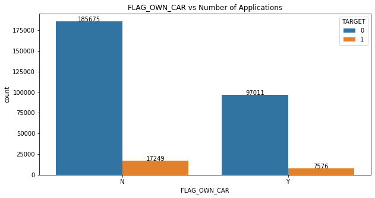

```python
# FLAG_OWN_CAR
cat_univariate_analysis('FLAG_OWN_CAR')
cat_proportions('FLAG_OWN_CAR')
```

```python
application_data['FLAG_OWN_CAR'].value_counts(normalize=True)
```

```
N   0.66
Y   0.34
Name: FLAG_OWN_CAR, dtype: float64
```

#### Owning A Car

```
TARGET 0
 [N, Y]
Categories (2, object): [N, Y]

TARGET 1
 [Y, N]
Categories (2, object): [Y, N]

All Other Cases (TARGET : 0)
+----+-------------------+---------+-----------+--------------------+----------------------+
|    | FLAG_OWN_REALTY   |   Count |   Percent |   Cumulative Count |   Cumulative Percent |
|----+-------------------+---------+-----------+--------------------+----------------------|
|  0 | Y                 |  196329 |  0.694513 |             196329 |             0.694513 |
|  1 | N                 |   86357 |  0.305487 |             282686 |             1        |
+----+-------------------+---------+-----------+--------------------+----------------------+

Clients with Payment Difficulties (TARGET : 1)
+----+-------------------+---------+-----------+--------------------+----------------------+
|    | FLAG_OWN_REALTY   |   Count |   Percent |   Cumulative Count |   Cumulative Percent |
|----+-------------------+---------+-----------+--------------------+----------------------|
|  0 | Y                 |   16983 |  0.684109 |              16983 |             0.684109 |
|  1 | N                 |    7842 |  0.315891 |              24825 |             1        |
+----+-------------------+---------+-----------+--------------------+----------------------+

Proportion of Y in Target 0 :  92.04
Proportion of Y in Target 1 :  7.96

Proportion of N in Target 0 :  91.68
Proportion of N in Target 1 :  8.32
```

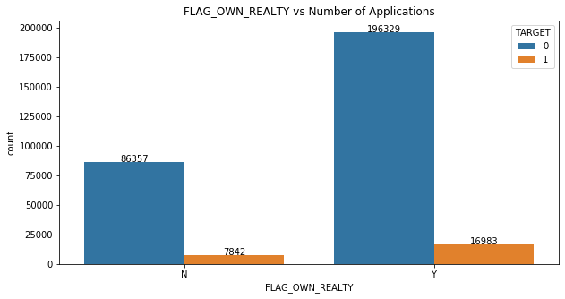

```python
# FLAG_OWN_REALTY
cat_univariate_analysis('FLAG_OWN_REALTY')
cat_proportions('FLAG_OWN_REALTY')
```

#### Owning Realty

- In Overall population of clients, 69.36% of people own real estate.
- In that group of people owning the real estate, 7.96% of people are having payment difficulties and the rest 92.04% belong to 'other cases'.
- In Overall population of clients, 30.63% of people do not own Realestate.
- In that group of people not owning the real estate, 8.32% of people are having payment difficulties and the rest 91.68% belong to 'other cases'.

**On closer comparision of above observations, we can infer that people who do not own Real-estate seem more likely to face payment difficulties than compared to the group of people owning the Real-estate.**

```
TARGET 0
 [Higher education, Secondary / secondary special, Incomplete higher, Lower secondary, Academic degree]
Categories (5, object): [Higher education, Secondary / secondary special, Incomplete higher, Lower secondary, Academic degree]

TARGET 1
 [Secondary / secondary special, Incomplete higher, Higher education, Lower secondary, Academic degree]
Categories (5, object): [Secondary / secondary special, Incomplete higher, Higher education, Lower secondary, Academic degree]

All Other Cases (TARGET : 0)
+----+-------------------------------+---------+-------------+--------------------+----------------------+
|    | NAME_EDUCATION_TYPE           |   Count |     Percent |   Cumulative Count |   Cumulative Percent |
|----+-------------------------------+---------+-------------+--------------------+----------------------|
|  0 | Secondary / secondary special |  198867 | 0.703491    |             198867 |             0.703491 |
|  1 | Higher education              |   70854 | 0.250646    |             269721 |             0.954136 |
|  2 | Incomplete higher             |    9405 | 0.0332701   |             279126 |             0.987407 |
|  3 | Lower secondary               |    3399 | 0.0120239   |             282525 |             0.99943  |
|  4 | Academic degree               |     161 | 0.000569537 |             282686 |             1        |
+----+-------------------------------+---------+-------------+--------------------+----------------------+

Clients with Payment Difficulties (TARGET : 1)
+----+-------------------------------+---------+-------------+--------------------+----------------------+
|    | NAME_EDUCATION_TYPE           |   Count |     Percent |   Cumulative Count |   Cumulative Percent |
|----+-------------------------------+---------+-------------+--------------------+----------------------|
|  0 | Secondary / secondary special |   19524 | 0.786465    |              19524 |             0.786465 |
|  1 | Higher education              |    4009 | 0.16149     |              23533 |             0.947956 |
|  2 | Incomplete higher             |     872 | 0.0351259   |              24405 |             0.983082 |
|  3 | Lower secondary               |     417 | 0.0167976   |              24822 |             0.999879 |
|  4 | Academic degree               |       3 | 0.000120846 |              24825 |             1        |
+----+-------------------------------+---------+-------------+--------------------+----------------------+

Proportion of Secondary / secondary special in Target 0 :  91.06
Proportion of Secondary / secondary special in Target 1 :  8.94

Proportion of Higher education in Target 0 :  94.64
Proportion of Higher education in Target 1 :  5.36

Proportion of Incomplete higher in Target 0 :  91.52
Proportion of Incomplete higher in Target 1 :  8.48

Proportion of Lower secondary in Target 0 :  89.07
Proportion of Lower secondary in Target 1 :  10.93

Proportion of Academic degree in Target 0 :  98.17
Proportion of Academic degree in Target 1 :  1.83
```

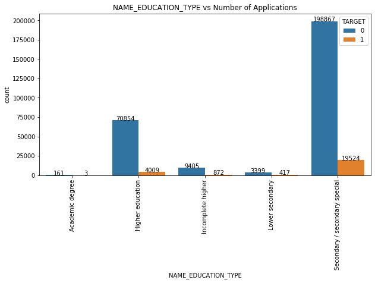

```python
#NAME_EDUCATION_TYPE

cat_univariate_analysis('NAME_EDUCATION_TYPE')
plt.xticks(rotation=90)
cat_proportions('NAME_EDUCATION_TYPE')
```

#### Highest Education

- 1.24% of the applicants are having education type of 'Lower secondary'
- Out of that 1.24%, 10.93% of them are likely to face Payment difficulties.
- 71% of the applicants are having education type of 'Secodary/seconday special' .
- Out of that 71%, 8.93% of them are likely to face Payment difficulties.
- 3.34% of the applicants are having education type of 'Incomplete higher'.
- Out of that 3.34%, 8.48% of them are likely to face Payment difficulties.
- 24.34% of the applicants are having education type of 'Higher education'.
- Out of that 24.34%, 5.36% of them are likely to face Payment difficulties.
- 0.05% of the applicants are having education type of 'Academic degree'.
- Out of that 0.05%, 1.83% of them are likely to face Payment difficulties.

**We can clearly infer from the above observations that higher the education, lesser is the risk of payment difficulties.**

```
TARGET 0
 [Married, Single / not married, Civil marriage, Widow, Separated, NaN]
Categories (5, object): [Married, Single / not married, Civil marriage, Widow, Separated]

TARGET 1
 [Single / not married, Widow, Married, Civil marriage, Separated]
Categories (5, object): [Single / not married, Widow, Married, Civil marriage, Separated]

All Other Cases (TARGET : 0)
+----+----------------------+---------+-----------+--------------------+----------------------+
|    | NAME_FAMILY_STATUS   |   Count |   Percent |   Cumulative Count |   Cumulative Percent |
|----+----------------------+---------+-----------+--------------------+----------------------|
|  0 | Married              |  181582 | 0.64235   |             181582 |             0.64235  |
|  1 | Single / not married |   40987 | 0.144992  |             222569 |             0.787342 |
|  2 | Civil marriage       |   26814 | 0.094855  |             249383 |             0.882197 |
|  3 | Separated            |   18150 | 0.064206  |             267533 |             0.946403 |
|  4 | Widow                |   15151 | 0.0535969 |             282684 |             1        |
+----+----------------------+---------+-----------+--------------------+----------------------+

Clients with Payment Difficulties (TARGET : 1)
+----+----------------------+---------+-----------+--------------------+----------------------+
|    | NAME_FAMILY_STATUS   |   Count |   Percent |   Cumulative Count |   Cumulative Percent |
|----+----------------------+---------+-----------+--------------------+----------------------|
|  0 | Married              |   14850 | 0.598187  |              14850 |             0.598187 |
|  1 | Single / not married |    4457 | 0.179537  |              19307 |             0.777724 |
|  2 | Civil marriage       |    2961 | 0.119275  |              22268 |             0.896999 |
|  3 | Separated            |    1620 | 0.0652568 |              23888 |             0.962256 |
|  4 | Widow                |     937 | 0.0377442 |              24825 |             1        |
+----+----------------------+---------+-----------+--------------------+----------------------+

Proportion of Single / not married in Target 0 :  90.19
Proportion of Single / not married in Target 1 :  9.81

Proportion of Married in Target 0 :  92.44
Proportion of Married in Target 1 :  7.56

Proportion of Civil marriage in Target 0 :  90.06
Proportion of Civil marriage in Target 1 :  9.94

Proportion of Widow in Target 0 :  94.18
Proportion of Widow in Target 1 :  5.82

Proportion of Separated in Target 0 :  91.81
Proportion of Separated in Target 1 :  8.19
```

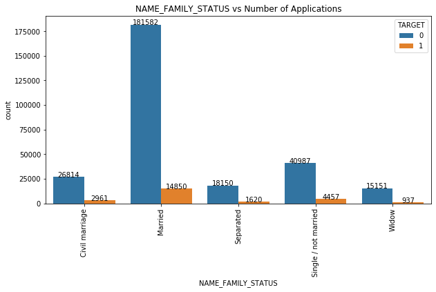

```python
#NAME_FAMILY_STATUS

cat_univariate_analysis('NAME_FAMILY_STATUS')
plt.xticks(rotation=90)
cat_proportions('NAME_FAMILY_STATUS')
```

#### Marital Status

- 5.2% of applicants have their family status as'Widow'
- Out of that 5.2%, 5.82% of them are likely to face Payment difficulties.
- 63.87% of applicants have their family status as'Married'
- Out of that 63.87%, 7.56% of them are likely to face Payment difficulties.
- 6.42% of applicants have their family status as'Seperated'
- Out of that 6.42%, 8.19% of them are likely to face Payment difficulties.
- 14.77% of applicants have their family status as'Single / not married'
- Out of that 14.77%, 9.81% of them are likely to face Payment difficulties.
- 9.68% of applicants have their family status as'Civil marriage'
- Out of that 9.68%, 9.94% of them are likely to face Payment difficulties.

**Based on the above obervations, we can infer that the applicants with NAME_FAMILY_STATUS as seperated or single or have higher risk of payment difficulties compared to that of Widow and Married.**

**For the purpose of this analysis, civil marriage and married are treated equal. They might be merged into the one category**

```
TARGET 0
 [House / apartment, Rented apartment, With parents, Municipal apartment, Office apartment, Co-op apartment]
Categories (6, object): [House / apartment, Rented apartment, With parents, Municipal apartment, Office apartment, Co-op apartment]

TARGET 1
 [House / apartment, With parents, Municipal apartment, Rented apartment, Office apartment, Co-op apartment]
Categories (6, object): [House / apartment, With parents, Municipal apartment, Rented apartment, Office apartment, Co-op apartment]

All Other Cases (TARGET : 0)
+----+---------------------+---------+------------+--------------------+----------------------+
|    | NAME_HOUSING_TYPE   |   Count |    Percent |   Cumulative Count |   Cumulative Percent |
|----+---------------------+---------+------------+--------------------+----------------------|
|  0 | House / apartment   |  251596 | 0.890019   |             251596 |             0.890019 |
|  1 | With parents        |   13104 | 0.0463553  |             264700 |             0.936375 |
|  2 | Municipal apartment |   10228 | 0.0361815  |             274928 |             0.972556 |
|  3 | Rented apartment    |    4280 | 0.0151405  |             279208 |             0.987697 |
|  4 | Office apartment    |    2445 | 0.00864917 |             281653 |             0.996346 |
|  5 | Co-op apartment     |    1033 | 0.00365423 |             282686 |             1        |
+----+---------------------+---------+------------+--------------------+----------------------+

Clients with Payment Difficulties (TARGET : 1)
+----+---------------------+---------+-----------+--------------------+----------------------+
|    | NAME_HOUSING_TYPE   |   Count |   Percent |   Cumulative Count |   Cumulative Percent |
|----+---------------------+---------+-----------+--------------------+----------------------|
|  0 | House / apartment   |   21272 | 0.856878  |              21272 |             0.856878 |
|  1 | With parents        |    1736 | 0.0699295 |              23008 |             0.926808 |
|  2 | Municipal apartment |     955 | 0.0384693 |              23963 |             0.965277 |
|  3 | Rented apartment    |     601 | 0.0242095 |              24564 |             0.989486 |
|  4 | Office apartment    |     172 | 0.0069285 |              24736 |             0.996415 |
|  5 | Co-op apartment     |      89 | 0.0035851 |              24825 |             1        |
+----+---------------------+---------+-----------+--------------------+----------------------+

Proportion of House / apartment in Target 0 :  92.2
Proportion of House / apartment in Target 1 :  7.8

Proportion of Rented apartment in Target 0 :  87.69
Proportion of Rented apartment in Target 1 :  12.31

Proportion of With parents in Target 0 :  88.3
Proportion of With parents in Target 1 :  11.7

Proportion of Municipal apartment in Target 0 :  91.46
Proportion of Municipal apartment in Target 1 :  8.54

Proportion of Office apartment in Target 0 :  93.43
Proportion of Office apartment in Target 1 :  6.57

Proportion of Co-op apartment in Target 0 :  92.07
Proportion of Co-op apartment in Target 1 :  7.93
```

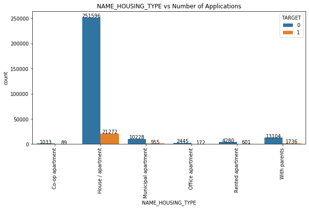

```python
#NAME_HOUSING_TYPE
cat_univariate_analysis('NAME_HOUSING_TYPE',figsize=(10,5))
plt.xticks(rotation=90)
cat_proportions('NAME_HOUSING_TYPE')
```

#### Housing Type

- 0.85% of applicants have their housing type as'Office apartment'
- Out of that 0.85%, 6.57% of them are likely to face Payment difficulties.
- 88.73% of applicants have their housing type as'House/ apartment'
- Out of that 88.73%, 7.8% of them are likely to face Payment difficulties.
- 0.36% of applicants have their housing type as'Co-op apartment'
- Out of that 0.36%, 7.93% of them are likely to face Payment difficulties.
- 3.63% of applicants have their housing type as'Municipal apartment'
- Out of that 3.63%, 8.54% of them are likely to face Payment difficulties.
- 4.82% of applicants have their housing type as'with parents'
- Out of that 4.82%, 11.7% of them are likely to face Payment difficulties.
- 1.58% of applicants have their housing type as'Rented apartment'
- Out of that 1.58%, 12.31% of them are likely to face Payment difficulties.

**Based on the above obervations, we can infer that the applicants with NAME_HOUSING_TYPE as 'Municipal apartment' or 'with parents' or 'Rented apartment ' have higher risk of payment difficulties compared to that of other housing types.**

```
posx and posy should be finite values
```

```
TARGET 0
 [250000-275000, 50000-75000, 125000-150000, 100000-125000, 75000-100000, ..., 325000-350000, 375000-400000, 400000-425000, 450000-475000, 475000-500000]
Length: 20
Categories (20, object): [25000-50000 < 50000-75000 < 75000-100000 < 100000-125000 ... 425000-450000 < 450000-475000 < 475000-500000 < 500000 and above]

TARGET 1
 [200000-225000, 100000-125000, 125000-150000, 75000-100000, 300000-325000, ..., 225000-250000, 375000-400000, 325000-350000, 450000-475000, 475000-500000]
Length: 20
Categories (20, object): [25000-50000 < 50000-75000 < 75000-100000 < 100000-125000 ... 425000-450000 < 450000-475000 < 475000-500000 < 500000 and above]

All Other Cases (TARGET : 0)
+----+------------------+---------+-------------+--------------------+----------------------+
|    | AMT_INCOME_CAT   |   Count |     Percent |   Cumulative Count |   Cumulative Percent |
|----+------------------+---------+-------------+--------------------+----------------------|
|  0 | 125000-150000    |   43837 | 0.155073    |              43837 |             0.155073 |
|  1 | 100000-125000    |   39860 | 0.141005    |              83697 |             0.296078 |
|  2 | 200000-225000    |   37595 | 0.132992    |             121292 |             0.42907  |
|  3 | 75000-100000     |   36450 | 0.128942    |             157742 |             0.558011 |
|  4 | 150000-175000    |   31685 | 0.112085    |             189427 |             0.670097 |
|  5 | 175000-200000    |   27190 | 0.0961845   |             216617 |             0.766281 |
|  6 | 50000-75000      |   17849 | 0.0631407   |             234466 |             0.829422 |
|  7 | 250000-275000    |   11846 | 0.0419052   |             246312 |             0.871327 |
|  8 | 225000-250000    |    6814 | 0.0241045   |             253126 |             0.895432 |
|  9 | 300000-325000    |    6342 | 0.0224348   |             259468 |             0.917866 |
| 10 | 350000-375000    |    4282 | 0.0151475   |             263750 |             0.933014 |
| 11 | 25000-50000      |    4174 | 0.0147655   |             267924 |             0.94778  |
| 12 | 275000-300000    |    4000 | 0.01415     |             271924 |             0.961929 |
| 13 | 425000-450000    |    2933 | 0.0103755   |             274857 |             0.972305 |
| 14 | 500000 and above |    2556 | 0.00904183  |             277413 |             0.981347 |
| 15 | 325000-350000    |    1987 | 0.007029    |             279400 |             0.988376 |
| 16 | 400000-425000    |    1696 | 0.00599959  |             281096 |             0.994375 |
| 17 | 375000-400000    |    1180 | 0.00417424  |             282276 |             0.99855  |
| 18 | 475000-500000    |     296 | 0.0010471   |             282572 |             0.999597 |
| 19 | 450000-475000    |     114 | 0.000403274 |             282686 |             1        |
+----+------------------+---------+-------------+--------------------+----------------------+

Clients with Payment Difficulties (TARGET : 1)
+----+------------------+---------+-------------+--------------------+----------------------+
|    | AMT_INCOME_CAT   |   Count |     Percent |   Cumulative Count |   Cumulative Percent |
|----+------------------+---------+-------------+--------------------+----------------------|
```

[output cut: 66 more lines]

```

Proportion of 325000-350000 in Target 0 :  93.64
Proportion of 325000-350000 in Target 1 :  6.36

Proportion of 375000-400000 in Target 0 :  93.28
Proportion of 375000-400000 in Target 1 :  6.72

Proportion of 400000-425000 in Target 0 :  93.65
Proportion of 400000-425000 in Target 1 :  6.35

Proportion of 450000-475000 in Target 0 :  91.2
Proportion of 450000-475000 in Target 1 :  8.8

Proportion of 475000-500000 in Target 0 :  94.87
Proportion of 475000-500000 in Target 1 :  5.13
```

```
posx and posy should be finite values
posx and posy should be finite values
posx and posy should be finite values
```

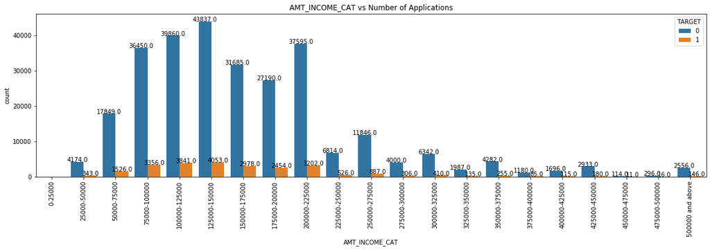

```python
#AMT_INCOME_CAT
cat_univariate_analysis('AMT_INCOME_CAT',figsize=(20,5))
plt.xticks(rotation=90)
cat_proportions('AMT_INCOME_CAT')
```

```python
# We will calculate the pecentage of "Clients with Payment difficulties" for every income category.
t0=application_data0['AMT_INCOME_CAT'].value_counts()
t1=application_data1['AMT_INCOME_CAT'].value_counts()
prop = 100*t1/(t1+t0)
print(tabulate(pd.DataFrame(prop), headers=['AMT_INCOME_CAT','PERCENTAGE'], tablefmt='psql'))
```

```
+------------------+--------------+
| AMT_INCOME_CAT   |   PERCENTAGE |
|------------------+--------------|
| 0-25000          |    nan       |
| 25000-50000      |      7.59354 |
| 50000-75000      |      7.87613 |
| 75000-100000     |      8.43089 |
| 100000-125000    |      8.78927 |
| 125000-150000    |      8.46314 |
| 150000-175000    |      8.59129 |
| 175000-200000    |      8.27824 |
| 200000-225000    |      7.84862 |
| 225000-250000    |      7.16621 |
| 250000-275000    |      6.96615 |
| 275000-300000    |      7.10636 |
| 300000-325000    |      6.07227 |
| 325000-350000    |      6.36192 |
| 350000-375000    |      5.62045 |
| 375000-400000    |      6.71937 |
| 400000-425000    |      6.35008 |
| 425000-450000    |      5.7822  |
| 450000-475000    |      8.8     |
| 475000-500000    |      5.12821 |
| 500000 and above |      5.4034  |
+------------------+--------------+
```

#### Income Category

```python
#CNT_CHILDREN
#Lets convert this into a categorical variable
application_data['CNT_CHILDREN']=application_data['CNT_CHILDREN'].astype('category')
application_data0['CNT_CHILDREN']=application_data0['CNT_CHILDREN'].astype('category')
application_data1['CNT_CHILDREN']=application_data1['CNT_CHILDREN'].astype('category')
```

```
TARGET 0
 [0, 1, 2, 3, 4, ..., 8, 12, 10, 19, 14]
Length: 13
Categories (13, int64): [0, 1, 2, 3, ..., 12, 10, 19, 14]

TARGET 1
 [0, 1, 3, 2, 4, 5, 9, 11, 6]
Categories (9, int64): [0, 1, 3, 2, ..., 5, 9, 11, 6]

All Other Cases (TARGET : 0)
+----+----------------+---------+-------------+--------------------+----------------------+
|    |   CNT_CHILDREN |   Count |     Percent |   Cumulative Count |   Cumulative Percent |
|----+----------------+---------+-------------+--------------------+----------------------|
|  0 |              0 |  198762 | 0.703119    |             198762 |             0.703119 |
|  1 |              1 |   55665 | 0.196915    |             254427 |             0.900034 |
|  2 |              2 |   24416 | 0.0863715   |             278843 |             0.986405 |
|  3 |              3 |    3359 | 0.0118824   |             282202 |             0.998288 |
|  4 |              4 |     374 | 0.00132302  |             282576 |             0.999611 |
|  5 |              5 |      77 | 0.000272387 |             282653 |             0.999883 |
|  6 |              6 |      15 | 5.30624e-05 |             282668 |             0.999936 |
|  7 |              7 |       7 | 2.47625e-05 |             282675 |             0.999961 |
|  8 |             14 |       3 | 1.06125e-05 |             282678 |             0.999972 |
|  9 |             19 |       2 | 7.07499e-06 |             282680 |             0.999979 |
| 10 |             12 |       2 | 7.07499e-06 |             282682 |             0.999986 |
| 11 |             10 |       2 | 7.07499e-06 |             282684 |             0.999993 |
| 12 |              8 |       2 | 7.07499e-06 |             282686 |             1        |
+----+----------------+---------+-------------+--------------------+----------------------+

Clients with Payment Difficulties (TARGET : 1)
+----+----------------+---------+-------------+--------------------+----------------------+
|    |   CNT_CHILDREN |   Count |     Percent |   Cumulative Count |   Cumulative Percent |
|----+----------------+---------+-------------+--------------------+----------------------|
|  0 |              0 |   16609 | 0.669043    |              16609 |             0.669043 |
|  1 |              1 |    5454 | 0.219698    |              22063 |             0.888741 |
|  2 |              2 |    2333 | 0.0939778   |              24396 |             0.982719 |
|  3 |              3 |     358 | 0.0144209   |              24754 |             0.99714  |
|  4 |              4 |      55 | 0.00221551  |              24809 |             0.999355 |
|  5 |              5 |       7 | 0.000281974 |              24816 |             0.999637 |
|  6 |              6 |       6 | 0.000241692 |              24822 |             0.999879 |
|  7 |              9 |       2 | 8.05639e-05 |              24824 |             0.99996  |
```

[output cut: 8 more lines]

```

Proportion of 2 in Target 0 :  91.28
Proportion of 2 in Target 1 :  8.72

Proportion of 3 in Target 0 :  90.37
Proportion of 3 in Target 1 :  9.63

Proportion of 4 in Target 0 :  87.18
Proportion of 4 in Target 1 :  12.82

Proportion of 5 in Target 0 :  91.67
Proportion of 5 in Target 1 :  8.33

Proportion of 6 in Target 0 :  71.43
Proportion of 6 in Target 1 :  28.57
```

[output not shown]

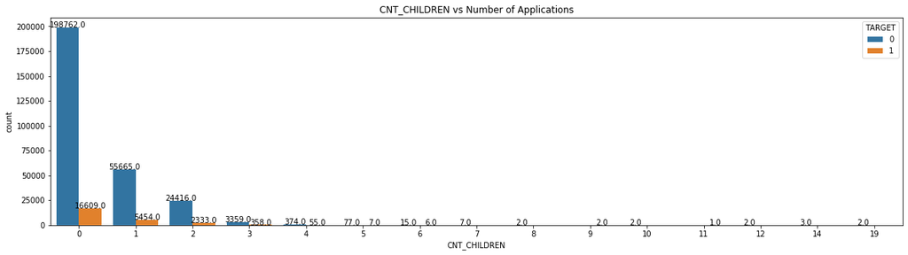

```python
#CNT_CHILDREN
cat_univariate_analysis('CNT_CHILDREN',figsize=(20,5))
column_name='CNT_CHILDREN'
cat_proportions('CNT_CHILDREN')
# values = application_data[column_name].unique()
# values=values.dropna()
# values = values.to_numpy()
# values.tolist()
# data0 = application_data0[column_name].value_counts().to_dict()
# data1 = application_data1[column_name].value_counts().to_dict()
# data = application_data[column_name].value_counts().to_dict()

# for i in values[:7]:
#     print('Proportion of '+ str(i) + ' in Target 0 : ', round(data0[i]*100/data[i],2))
#     print('Proportion of '+ str(i) + ' in Target 1 : ', round(data1[i]*100/data[i],2),'\n' )
```

```python
# Calculating the pecentage of "Clients with Payment difficulties" for every income category.
t0=application_data0['CNT_CHILDREN'].value_counts()
t1=application_data1['CNT_CHILDREN'].value_counts()
prop = 100*t1/(t1+t0)

print(tabulate(pd.DataFrame(prop), headers=['No of Children','Percentage'], tablefmt='psql'))
```

```
+------------------+--------------+
|   No of Children |   Percentage |
|------------------+--------------|
|                0 |      7.71181 |
|                1 |      8.92358 |
|                2 |      8.72182 |
|                3 |      9.63142 |
|                4 |     12.8205  |
|                5 |      8.33333 |
|                6 |     28.5714  |
|                7 |    nan       |
|                8 |    nan       |
|                9 |    nan       |
|               10 |    nan       |
|               11 |    nan       |
|               12 |    nan       |
|               14 |    nan       |
|               19 |    nan       |
+------------------+--------------+
```

#### Number of Children

```
posx and posy should be finite values
posx and posy should be finite values
```

```
TARGET 0
 [2.00, 1.00, 3.00, 4.00, 5.00, ..., 14.00, 12.00, 20.00, 15.00, 16.00]
Length: 16
Categories (15, float64): [2.00, 1.00, 3.00, 4.00, ..., 12.00, 20.00, 15.00, 16.00]

TARGET 1
 [1.00, 2.00, 5.00, 3.00, 4.00, ..., 7.00, 10.00, 13.00, 8.00, 11.00]
Length: 11
Categories (11, float64): [1.00, 2.00, 5.00, 3.00, ..., 10.00, 13.00, 8.00, 11.00]

All Other Cases (TARGET : 0)
+----+-------------------+---------+-------------+--------------------+----------------------+
|    |   CNT_FAM_MEMBERS |   Count |     Percent |   Cumulative Count |   Cumulative Percent |
|----+-------------------+---------+-------------+--------------------+----------------------|
|  0 |                 2 |  146348 | 0.517709    |             146348 |             0.517709 |
|  1 |                 1 |   62172 | 0.219935    |             208520 |             0.737643 |
|  2 |                 3 |   47993 | 0.169776    |             256513 |             0.90742  |
|  3 |                 4 |   22561 | 0.07981     |             279074 |             0.98723  |
|  4 |                 5 |    3151 | 0.0111467   |             282225 |             0.998376 |
|  5 |                 6 |     353 | 0.00124874  |             282578 |             0.999625 |
|  6 |                 7 |      75 | 0.000265314 |             282653 |             0.99989  |
|  7 |                 8 |      14 | 4.95253e-05 |             282667 |             0.99994  |
|  8 |                 9 |       6 | 2.12251e-05 |             282673 |             0.999961 |
|  9 |                20 |       2 | 7.07504e-06 |             282675 |             0.999968 |
| 10 |                16 |       2 | 7.07504e-06 |             282677 |             0.999975 |
| 11 |                14 |       2 | 7.07504e-06 |             282679 |             0.999982 |
| 12 |                12 |       2 | 7.07504e-06 |             282681 |             0.999989 |
| 13 |                10 |       2 | 7.07504e-06 |             282683 |             0.999996 |
| 14 |                15 |       1 | 3.53752e-06 |             282684 |             1        |
+----+-------------------+---------+-------------+--------------------+----------------------+

Clients with Payment Difficulties (TARGET : 1)
+----+-------------------+---------+-------------+--------------------+----------------------+
|    |   CNT_FAM_MEMBERS |   Count |     Percent |   Cumulative Count |   Cumulative Percent |
|----+-------------------+---------+-------------+--------------------+----------------------|
|  0 |                 2 |   12009 | 0.483746    |              12009 |             0.483746 |
|  1 |                 1 |    5675 | 0.2286      |              17684 |             0.712346 |
|  2 |                 3 |    4608 | 0.185619    |              22292 |             0.897966 |
|  3 |                 4 |    2136 | 0.0860423   |              24428 |             0.984008 |
|  4 |                 5 |     327 | 0.0131722   |              24755 |             0.99718  |
```

[output cut: 43 more lines]

```

Proportion of 12.0 in Target 0 :  100.0
Proportion of 12.0 in Target 1 :  0.0

Proportion of 20.0 in Target 0 :  100.0
Proportion of 20.0 in Target 1 :  0.0

Proportion of 15.0 in Target 0 :  100.0
Proportion of 15.0 in Target 1 :  0.0

Proportion of 16.0 in Target 0 :  100.0
Proportion of 16.0 in Target 1 :  0.0

Proportion of 11.0 in Target 0 :  0.0
Proportion of 11.0 in Target 1 :  100.0
```

[output not shown]

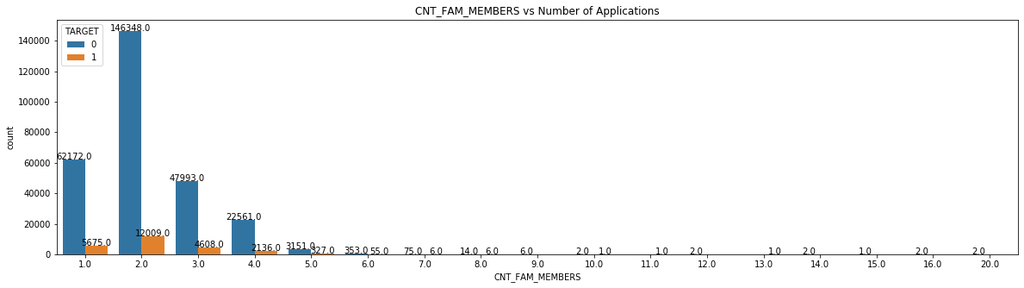

```python
#CNT_FAM_MEMBERS
cat_univariate_analysis('CNT_FAM_MEMBERS',figsize=(20,5))
cat_proportions('CNT_FAM_MEMBERS')
```

#### Number of Family members

```
All Other Cases (TARGET : 0)
count   282,686.00
mean     69,668.81
std     140,983.36
min           0.00
25%         967.00
50%       2,304.00
75%       6,074.00
max     365,243.00
Name: DAYS_EMPLOYED, dtype: float64

Clients with Payment Difficulties (TARGET : 1)
count    24,825.00
mean     45,587.32
std     118,303.30
min           0.00
25%         677.00
50%       1,458.00
75%       3,280.00
max     365,243.00
Name: DAYS_EMPLOYED, dtype: float64
```

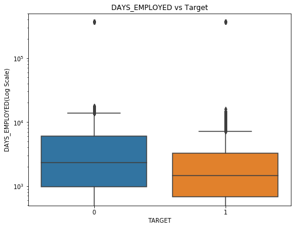

```python
#DAYS_EMPLOYED.
num_univariate_analysis('DAYS_EMPLOYED','log')
```

#### Number of Days Employed

- If we observe the above box plot, we can clearly notice the outliers, so lets concentrate on median.
- The applicants with payment difficulties have lesser median and IQR compared to "all other cases". So, greater the DAYS_EMPLOYED, lesser is the risk of payment difficulties.

```
posx and posy should be finite values
posx and posy should be finite values
```

```
TARGET 0
 [State servant, Working, Commercial associate, Pensioner, Unemployed, Student, Businessman, Maternity leave]
Categories (8, object): [State servant, Working, Commercial associate, Pensioner, Unemployed, Student, Businessman, Maternity leave]

TARGET 1
 [Working, Commercial associate, Pensioner, State servant, Unemployed, Maternity leave]
Categories (6, object): [Working, Commercial associate, Pensioner, State servant, Unemployed, Maternity leave]

All Other Cases (TARGET : 0)
+----+----------------------+---------+-------------+--------------------+----------------------+
|    | NAME_INCOME_TYPE     |   Count |     Percent |   Cumulative Count |   Cumulative Percent |
|----+----------------------+---------+-------------+--------------------+----------------------|
|  0 | Working              |  143550 | 0.507807    |             143550 |             0.507807 |
|  1 | Commercial associate |   66257 | 0.234384    |             209807 |             0.742191 |
|  2 | Pensioner            |   52380 | 0.185294    |             262187 |             0.927485 |
|  3 | State servant        |   20454 | 0.0723559   |             282641 |             0.999841 |
|  4 | Student              |      18 | 6.36749e-05 |             282659 |             0.999904 |
|  5 | Unemployed           |      14 | 4.95249e-05 |             282673 |             0.999954 |
|  6 | Businessman          |      10 | 3.53749e-05 |             282683 |             0.999989 |
|  7 | Maternity leave      |       3 | 1.06125e-05 |             282686 |             1        |
+----+----------------------+---------+-------------+--------------------+----------------------+

Clients with Payment Difficulties (TARGET : 1)
+----+----------------------+---------+-------------+--------------------+----------------------+
|    | NAME_INCOME_TYPE     |   Count |     Percent |   Cumulative Count |   Cumulative Percent |
|----+----------------------+---------+-------------+--------------------+----------------------|
|  0 | Working              |   15224 | 0.613253    |              15224 |             0.613253 |
|  1 | Commercial associate |    5360 | 0.215911    |              20584 |             0.829164 |
|  2 | Pensioner            |    2982 | 0.120121    |              23566 |             0.949285 |
|  3 | State servant        |    1249 | 0.0503122   |              24815 |             0.999597 |
|  4 | Unemployed           |       8 | 0.000322256 |              24823 |             0.999919 |
|  5 | Maternity leave      |       2 | 8.05639e-05 |              24825 |             1        |
+----+----------------------+---------+-------------+--------------------+----------------------+

Proportion of Working in Target 0 :  90.41
Proportion of Working in Target 1 :  9.59

Proportion of State servant in Target 0 :  94.25
Proportion of State servant in Target 1 :  5.75

Proportion of Commercial associate in Target 0 :  92.52
Proportion of Commercial associate in Target 1 :  7.48

Proportion of Pensioner in Target 0 :  94.61
Proportion of Pensioner in Target 1 :  5.39

Proportion of Unemployed in Target 0 :  63.64
Proportion of Unemployed in Target 1 :  36.36

Proportion of Student in Target 0 :  100.0
Proportion of Student in Target 1 :  0.0

Proportion of Businessman in Target 0 :  100.0
Proportion of Businessman in Target 1 :  0.0

Proportion of Maternity leave in Target 0 :  60.0
Proportion of Maternity leave in Target 1 :  40.0
```

```
posx and posy should be finite values
posx and posy should be finite values
```

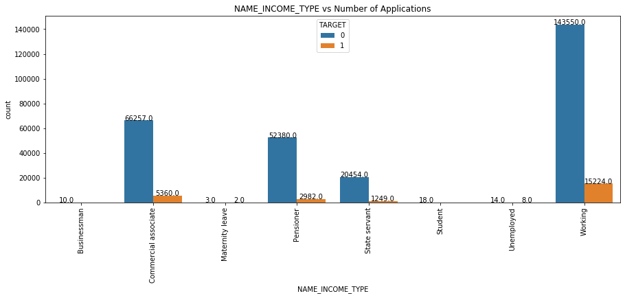

```python
#NAME_INCOME_TYPE
cat_univariate_analysis('NAME_INCOME_TYPE',figsize=(15,5))
plt.xticks(rotation=90)
cat_proportions('NAME_INCOME_TYPE')
```

#### Income type

- 52% of applicants have their NAME_INCOME_TYPE as'Working'.
- Out of that 52%, 9.59% of them are likely to face Payment difficulties.
- 23% of applicants have their NAME_INCOME_TYPE as'Commercial associate'
- Out of that 23%, 7.48% of them are likely to face Payment difficulties.
- 7% of applicants have their NAME_INCOME_TYPE as'State servant'
- Out of that 7%, 5.75% of them are likely to face Payment difficulties.
- 18% of applicants have their NAME_INCOME_TYPE as'Pensioner'
- Out of that 18%, 5.39% of them are likely to face Payment difficulties.

**From the above Graph and proportions, we can infer that Pensioners and state servants have lower risk of facing payment difficulties compared to the Working and Commercial associates.**

**Unemployed,Student,Businessman and Maternity leave cannot be inferred because of the reason that they are not well populated.**

```
All Other Cases (TARGET : 0)
count   282,685.00
mean        976.39
std         831.21
min           0.00
25%         281.00
50%         776.00
75%       1,586.00
max       4,292.00
Name: DAYS_LAST_PHONE_CHANGE, dtype: float64

Clients with Payment Difficulties (TARGET : 1)
count   24,825.00
mean       808.80
std        758.09
min          0.00
25%        194.00
50%        594.00
75%      1,301.00
max      4,070.00
Name: DAYS_LAST_PHONE_CHANGE, dtype: float64
```

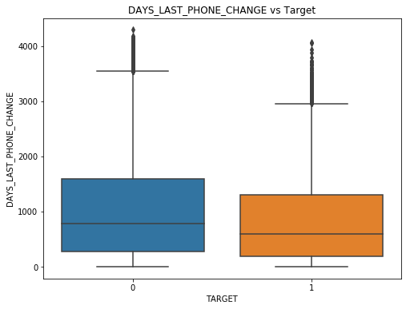

```python
#DAYS_LAST_PHONE_CHANGE
application_data['DAYS_LAST_PHONE_CHANGE'] = np.abs(application_data['DAYS_LAST_PHONE_CHANGE'])
application_data0['DAYS_LAST_PHONE_CHANGE'] = np.abs(application_data0['DAYS_LAST_PHONE_CHANGE'])
application_data1['DAYS_LAST_PHONE_CHANGE'] = np.abs(application_data1['DAYS_LAST_PHONE_CHANGE'])
num_univariate_analysis('DAYS_LAST_PHONE_CHANGE')
```

#### Days Since Phone Number Was Changed.

- From the above boxplot, we can clearly notice that the median for 'all other cases' is 776 days and the median for 'Clients with payment difficulties' is 594 days.
- By this, we can clearly infer that,lesser the days since last phone change, greater is the risk of payment difficulties

```
TARGET 0
 [1, 0]
Categories (2, int64): [1, 0]

TARGET 1
 [1, 0]
Categories (2, int64): [1, 0]

All Other Cases (TARGET : 0)
+----+--------------------+---------+------------+--------------------+----------------------+
|    |   FLAG_CONT_MOBILE |   Count |    Percent |   Cumulative Count |   Cumulative Percent |
|----+--------------------+---------+------------+--------------------+----------------------|
|  0 |                  1 |  282157 | 0.998129   |             282157 |             0.998129 |
|  1 |                  0 |     529 | 0.00187133 |             282686 |             1        |
+----+--------------------+---------+------------+--------------------+----------------------+

Clients with Payment Difficulties (TARGET : 1)
+----+--------------------+---------+------------+--------------------+----------------------+
|    |   FLAG_CONT_MOBILE |   Count |    Percent |   Cumulative Count |   Cumulative Percent |
|----+--------------------+---------+------------+--------------------+----------------------|
|  0 |                  1 |   24780 | 0.998187   |              24780 |             0.998187 |
|  1 |                  0 |      45 | 0.00181269 |              24825 |             1        |
+----+--------------------+---------+------------+--------------------+----------------------+

Proportion of 1 in Target 0 :  91.93
Proportion of 1 in Target 1 :  8.07

Proportion of 0 in Target 0 :  92.16
Proportion of 0 in Target 1 :  7.84
```

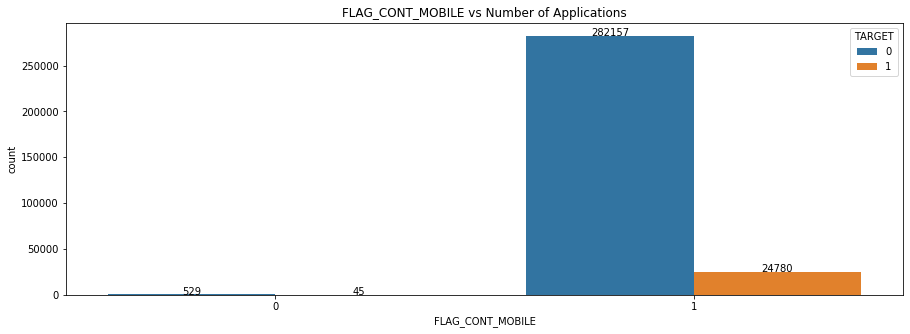

```python
#FLAG_CONT_MOBILE
cat_univariate_analysis('FLAG_CONT_MOBILE',figsize=(15,5))
cat_proportions('FLAG_CONT_MOBILE')
```

#### Flag Whether Mobile Phone Was Reachable

- From the above plot, we can observe that 0.18% applicants mobile numbers were not reachable.
- From the people whose mobiles numbers were reachable, 8.07% of them are likely to face Payment difficulties, whereas the people whose mobile numbers were'nt reachable, 7.84% of them are likely to face Payment difficulties.

**From these we cannot infer a relationship between FLAG_CONT_MOBILE and TARGET variable.**

```
TARGET 0
 [0, 1]
Categories (2, int64): [0, 1]

TARGET 1
 [0, 1]
Categories (2, int64): [0, 1]

All Other Cases (TARGET : 0)
+----+--------------+---------+-----------+--------------------+----------------------+
|    |   FLAG_EMAIL |   Count |   Percent |   Cumulative Count |   Cumulative Percent |
|----+--------------+---------+-----------+--------------------+----------------------|
|  0 |            0 |  266618 | 0.94316   |             266618 |              0.94316 |
|  1 |            1 |   16068 | 0.0568405 |             282686 |              1       |
+----+--------------+---------+-----------+--------------------+----------------------+

Clients with Payment Difficulties (TARGET : 1)
+----+--------------+---------+-----------+--------------------+----------------------+
|    |   FLAG_EMAIL |   Count |   Percent |   Cumulative Count |   Cumulative Percent |
|----+--------------+---------+-----------+--------------------+----------------------|
|  0 |            0 |   23451 | 0.944653  |              23451 |             0.944653 |
|  1 |            1 |    1374 | 0.0553474 |              24825 |             1        |
+----+--------------+---------+-----------+--------------------+----------------------+

Proportion of 0 in Target 0 :  91.92
Proportion of 0 in Target 1 :  8.08

Proportion of 1 in Target 0 :  92.12
Proportion of 1 in Target 1 :  7.88
```

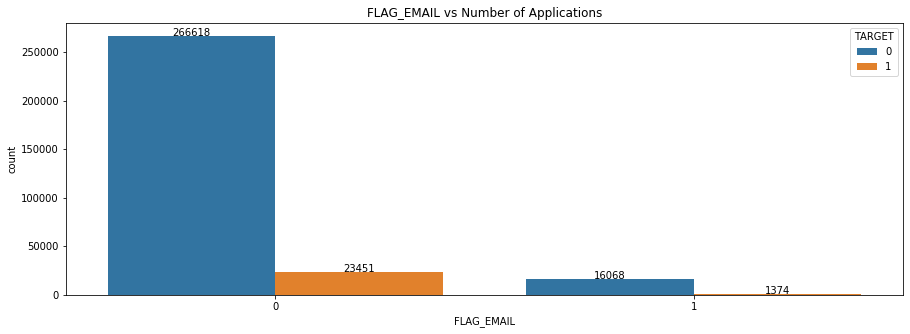

```python
#FLAG_EMAIL.
cat_univariate_analysis('FLAG_EMAIL',figsize=(15,5))
cat_proportions('FLAG_EMAIL')
```

#### Whether E-mail Was Provided

- From the above plot and proportions, we can clearly see that 94.3% of applicants have not given the E-mail address.
- Out of 94.3%, 8.08% are likely to have payment difficulties.
- From the above plot and proportions, we can clearly see that 5.7% of applicants have provided the E-mail address.
- Out of 5.7%, 7.88% are likely to have paymenr difficulties.

**From these we cannot infer a relationship between FLAG_EMAIL and TARGET variable because they stand in similar grounds.**

```
TARGET 0
 [1, 0]
Categories (2, int64): [1, 0]

TARGET 1
 [1]
Categories (1, int64): [1]

All Other Cases (TARGET : 0)
+----+--------------+---------+-------------+--------------------+----------------------+
|    |   FLAG_MOBIL |   Count |     Percent |   Cumulative Count |   Cumulative Percent |
|----+--------------+---------+-------------+--------------------+----------------------|
|  0 |            1 |  282685 | 0.999996    |             282685 |             0.999996 |
|  1 |            0 |       1 | 3.53749e-06 |             282686 |             1        |
+----+--------------+---------+-------------+--------------------+----------------------+

Clients with Payment Difficulties (TARGET : 1)
+----+--------------+---------+-----------+--------------------+----------------------+
|    |   FLAG_MOBIL |   Count |   Percent |   Cumulative Count |   Cumulative Percent |
|----+--------------+---------+-----------+--------------------+----------------------|
|  0 |            1 |   24825 |         1 |              24825 |                    1 |
+----+--------------+---------+-----------+--------------------+----------------------+
```

```
posx and posy should be finite values
posx and posy should be finite values
```

```
Proportion of 1 in Target 0 :  91.93
Proportion of 1 in Target 1 :  8.07

Proportion of 0 in Target 0 :  100.0
Proportion of 0 in Target 1 :  0.0
```

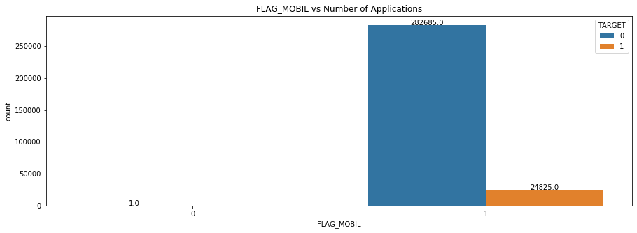

```python
#FLAG_MOBIL
cat_univariate_analysis('FLAG_MOBIL',figsize=(15,5))
cat_proportions('FLAG_MOBIL')
```

#### Mobile Number

- 99.9% of them have given their mobile numbers. Out of those 99%, 8.07% have payment difficulties.
- There is only one applicant who failed to provide the mobile number, since this number is small and negligible, we cannot infer using this data.

```
TARGET 0
 [0, 1]
Categories (2, int64): [0, 1]

TARGET 1
 [0, 1]
Categories (2, int64): [0, 1]

All Other Cases (TARGET : 0)
+----+---------------------------+---------+-----------+--------------------+----------------------+
|    |   LIVE_CITY_NOT_WORK_CITY |   Count |   Percent |   Cumulative Count |   Cumulative Percent |
|----+---------------------------+---------+-----------+--------------------+----------------------|
|  0 |                         0 |  232974 |  0.824144 |             232974 |             0.824144 |
|  1 |                         1 |   49712 |  0.175856 |             282686 |             1        |
+----+---------------------------+---------+-----------+--------------------+----------------------+

Clients with Payment Difficulties (TARGET : 1)
+----+---------------------------+---------+-----------+--------------------+----------------------+
|    |   LIVE_CITY_NOT_WORK_CITY |   Count |   Percent |   Cumulative Count |   Cumulative Percent |
|----+---------------------------+---------+-----------+--------------------+----------------------|
|  0 |                         0 |   19322 |  0.778328 |              19322 |             0.778328 |
|  1 |                         1 |    5503 |  0.221672 |              24825 |             1        |
+----+---------------------------+---------+-----------+--------------------+----------------------+

Proportion of 0 in Target 0 :  92.34
Proportion of 0 in Target 1 :  7.66

Proportion of 1 in Target 0 :  90.03
Proportion of 1 in Target 1 :  9.97
```

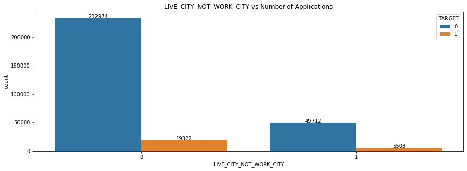

```python
#LIVE_CITY_NOT_WORK_CITY
cat_univariate_analysis('LIVE_CITY_NOT_WORK_CITY',figsize=(15,5))
cat_proportions('LIVE_CITY_NOT_WORK_CITY')
```